# Classification Models - practical example

For the research, we initiated an analysis of traffic collision data to identify factors contributing to the frequency and severity of incidents. The dataset includes a diverse range of variables from over 190,000 records, providing a substantial base for our statistical models. Our primary focus is on the COLLISIONTYPE variable, which categorizes the nature of collisions.

The data will undergo preprocessing to address missing values and convert categorical variables into a machine-readable format. An exploratory data analysis will follow to ascertain the distributions and inter-variable relationships. We will then employ statistical and machine learning algorithms suitable for multi-class classification tasks.

The objective of this study is to develop predictive models that can assist in the formulation of targeted strategies and choose the best based on the performance.

Structure:

1. Data preparation and EDA
2. Split
3. Logistic regression
4. SVM
5. KNN
6. Decision Tree
7. Neural Networks

```python
# we upload necessary libraries for preprocessing:

import numpy as np
import pandas as pd
import seaborn as sn
import matplotlib.pyplot as plt
```

```python
# download our data file
raw_data = pd.read_csv('Data_Collisions.csv',  low_memory=False)

raw_data.head()
```

|  | SEVERITYCODE | X | Y | OBJECTID | INCKEY | COLDETKEY | REPORTNO | STATUS | ADDRTYPE | INTKEY | ... | ROADCOND | LIGHTCOND | PEDROWNOTGRNT | SDOTCOLNUM | SPEEDING | ST_COLCODE | ST_COLDESC | SEGLANEKEY | CROSSWALKKEY | HITPARKEDCAR |
| --- | --- | --- | --- | --- | --- | --- | --- | --- | --- | --- | --- | --- | --- | --- | --- | --- | --- | --- | --- | --- | --- |
| 0 | 2 | -122.323148 | 47.703140 | 1 | 1307 | 1307 | 3502005 | Matched | Intersection | 37475.0 | ... | Wet | Daylight | NaN | NaN | NaN | 10 | Entering at angle | 0 | 0 | N |
| 1 | 1 | -122.347294 | 47.647172 | 2 | 52200 | 52200 | 2607959 | Matched | Block | NaN | ... | Wet | Dark - Street Lights On | NaN | 6354039.0 | NaN | 11 | From same direction - both going straight - bo... | 0 | 0 | N |
| 2 | 1 | -122.334540 | 47.607871 | 3 | 26700 | 26700 | 1482393 | Matched | Block | NaN | ... | Dry | Daylight | NaN | 4323031.0 | NaN | 32 | One parked--one moving | 0 | 0 | N |
| 3 | 1 | -122.334803 | 47.604803 | 4 | 1144 | 1144 | 3503937 | Matched | Block | NaN | ... | Dry | Daylight | NaN | NaN | NaN | 23 | From same direction - all others | 0 | 0 | N |
| 4 | 2 | -122.306426 | 47.545739 | 5 | 17700 | 17700 | 1807429 | Matched | Intersection | 34387.0 | ... | Wet | Daylight | NaN | 4028032.0 | NaN | 10 | Entering at angle | 0 | 0 | N |

5 rows × 38 columns

After uploading the set, we can gather more description:

```python
raw_data.info()
```

```
<class 'pandas.core.frame.DataFrame'>
RangeIndex: 194673 entries, 0 to 194672
Data columns (total 38 columns):
 #   Column          Non-Null Count   Dtype
---  ------          --------------   -----
 0   SEVERITYCODE    194673 non-null  int64
 1   X               189339 non-null  float64
 2   Y               189339 non-null  float64
 3   OBJECTID        194673 non-null  int64
 4   INCKEY          194673 non-null  int64
 5   COLDETKEY       194673 non-null  int64
 6   REPORTNO        194673 non-null  object
 7   STATUS          194673 non-null  object
 8   ADDRTYPE        192747 non-null  object
 9   INTKEY          65070 non-null   float64
```

[output cut: 30 more lines]

GPT The dataset under analysis comprises 194,673 entries with 38 columns, capturing various aspects of traffic collisions. Each entry represents a unique incident with attributes ranging from geographical coordinates (X, Y) to more descriptive data such as COLLISIONTYPE and JUNCTIONTYPE.

There are several numeric fields, including SEVERITYCODE, PERSONCOUNT, PEDCOUNT, PEDCYLCOUNT, and VEHCOUNT, all of which are complete with no missing values. However, a subset of the data, particularly categorical variables like INATTENTIONIND, PEDROWNOTGRNT, and SPEEDING, exhibit a significant number of missing entries, indicating a need for careful preprocessing.

```python
raw_data.nunique()
```

```
SEVERITYCODE           2
X                  23563
Y                  23839
OBJECTID          194673
INCKEY            194673
COLDETKEY         194673
REPORTNO          194670
STATUS                 2
ADDRTYPE               3
INTKEY              7614
LOCATION           24102
EXCEPTRSNCODE          2
EXCEPTRSNDESC          1
SEVERITYCODE.1         2
SEVERITYDESC           2
COLLISIONTYPE         10
PERSONCOUNT           47
PEDCOUNT               7
PEDCYLCOUNT            3
VEHCOUNT              13
INCDATE             5985
INCDTTM           162058
JUNCTIONTYPE           7
SDOT_COLCODE          39
SDOT_COLDESC          39
INATTENTIONIND         1
UNDERINFL              4
WEATHER               11
ROADCOND               9
LIGHTCOND              9
PEDROWNOTGRNT          1
SDOTCOLNUM        114932
SPEEDING               1
ST_COLCODE            63
ST_COLDESC            62
SEGLANEKEY          1955
CROSSWALKKEY        2198
HITPARKEDCAR           2
dtype: int64
```

This line of code presents us with the total amount of unique values in each column. The main interest is on the COLLISIONTYPE variable, with its ten unique classes (the number can be considered manageable to avoid problems of high multidimensiality).

```python
raw_data.describe()
```

|  | SEVERITYCODE | X | Y | OBJECTID | INCKEY | COLDETKEY | INTKEY | SEVERITYCODE.1 | PERSONCOUNT | PEDCOUNT | PEDCYLCOUNT | VEHCOUNT | SDOT_COLCODE | SDOTCOLNUM | SEGLANEKEY | CROSSWALKKEY |
| --- | --- | --- | --- | --- | --- | --- | --- | --- | --- | --- | --- | --- | --- | --- | --- | --- |
| count | 194673.000000 | 189339.000000 | 189339.000000 | 194673.000000 | 194673.000000 | 194673.000000 | 65070.000000 | 194673.000000 | 194673.000000 | 194673.000000 | 194673.000000 | 194673.000000 | 194673.000000 | 1.149360e+05 | 194673.000000 | 1.946730e+05 |
| mean | 1.298901 | -122.330518 | 47.619543 | 108479.364930 | 141091.456350 | 141298.811381 | 37558.450576 | 1.298901 | 2.444427 | 0.037139 | 0.028391 | 1.920780 | 13.867768 | 7.972521e+06 | 269.401114 | 9.782452e+03 |
| std | 0.457778 | 0.029976 | 0.056157 | 62649.722558 | 86634.402737 | 86986.542110 | 51745.990273 | 0.457778 | 1.345929 | 0.198150 | 0.167413 | 0.631047 | 6.868755 | 2.553533e+06 | 3315.776055 | 7.226926e+04 |
| min | 1.000000 | -122.419091 | 47.495573 | 1.000000 | 1001.000000 | 1001.000000 | 23807.000000 | 1.000000 | 0.000000 | 0.000000 | 0.000000 | 0.000000 | 0.000000 | 1.007024e+06 | 0.000000 | 0.000000e+00 |
| 25% | 1.000000 | -122.348673 | 47.575956 | 54267.000000 | 70383.000000 | 70383.000000 | 28667.000000 | 1.000000 | 2.000000 | 0.000000 | 0.000000 | 2.000000 | 11.000000 | 6.040015e+06 | 0.000000 | 0.000000e+00 |
| 50% | 1.000000 | -122.330224 | 47.615369 | 106912.000000 | 123363.000000 | 123363.000000 | 29973.000000 | 1.000000 | 2.000000 | 0.000000 | 0.000000 | 2.000000 | 13.000000 | 8.023022e+06 | 0.000000 | 0.000000e+00 |
| 75% | 2.000000 | -122.311937 | 47.663664 | 162272.000000 | 203319.000000 | 203459.000000 | 33973.000000 | 2.000000 | 3.000000 | 0.000000 | 0.000000 | 2.000000 | 14.000000 | 1.015501e+07 | 0.000000 | 0.000000e+00 |
| max | 2.000000 | -122.238949 | 47.734142 | 219547.000000 | 331454.000000 | 332954.000000 | 757580.000000 | 2.000000 | 81.000000 | 6.000000 | 2.000000 | 12.000000 | 69.000000 | 1.307202e+07 | 525241.000000 | 5.239700e+06 |

```python
col_names = raw_data.columns.values
col_names
```

```
array(['SEVERITYCODE', 'X', 'Y', 'OBJECTID', 'INCKEY', 'COLDETKEY',
       'REPORTNO', 'STATUS', 'ADDRTYPE', 'INTKEY', 'LOCATION',
       'EXCEPTRSNCODE', 'EXCEPTRSNDESC', 'SEVERITYCODE.1', 'SEVERITYDESC',
       'COLLISIONTYPE', 'PERSONCOUNT', 'PEDCOUNT', 'PEDCYLCOUNT',
       'VEHCOUNT', 'INCDATE', 'INCDTTM', 'JUNCTIONTYPE', 'SDOT_COLCODE',
       'SDOT_COLDESC', 'INATTENTIONIND', 'UNDERINFL', 'WEATHER',
       'ROADCOND', 'LIGHTCOND', 'PEDROWNOTGRNT', 'SDOTCOLNUM', 'SPEEDING',
       'ST_COLCODE', 'ST_COLDESC', 'SEGLANEKEY', 'CROSSWALKKEY',
       'HITPARKEDCAR'], dtype=object)
```

One of the important aspect of pre-processing is identifying null values. We can do it by creating a dictionary with columns names and shares of empty values.

```python
nan_dict, empty_col= {}, []
for col in col_names:
    if raw_data[col].isnull().any():
        nan_dict[col] = round(((raw_data[col].isnull().sum() / len(raw_data[col])) * 100),2)
        empty_col.append(col)
nan_dict, empty_col
```

```
({'X': 2.74,
  'Y': 2.74,
  'ADDRTYPE': 0.99,
  'INTKEY': 66.57,
  'LOCATION': 1.38,
  'EXCEPTRSNCODE': 56.43,
  'EXCEPTRSNDESC': 97.1,
  'COLLISIONTYPE': 2.52,
  'JUNCTIONTYPE': 3.25,
  'INATTENTIONIND': 84.69,
  'UNDERINFL': 2.51,
  'WEATHER': 2.61,
  'ROADCOND': 2.57,
  'LIGHTCOND': 2.66,
  'PEDROWNOTGRNT': 97.6,
  'SDOTCOLNUM': 40.96,
  'SPEEDING': 95.21,
  'ST_COLCODE': 0.01,
  'ST_COLDESC': 2.52},
 ['X',
  'Y',
  'ADDRTYPE',
  'INTKEY',
  'LOCATION',
  'EXCEPTRSNCODE',
  'EXCEPTRSNDESC',
  'COLLISIONTYPE',
  'JUNCTIONTYPE',
  'INATTENTIONIND',
  'UNDERINFL',
  'WEATHER',
  'ROADCOND',
  'LIGHTCOND',
  'PEDROWNOTGRNT',
  'SDOTCOLNUM',
  'SPEEDING',
  'ST_COLCODE',
  'ST_COLDESC'])
```

The results can be presented as a heatmap for better understanding:

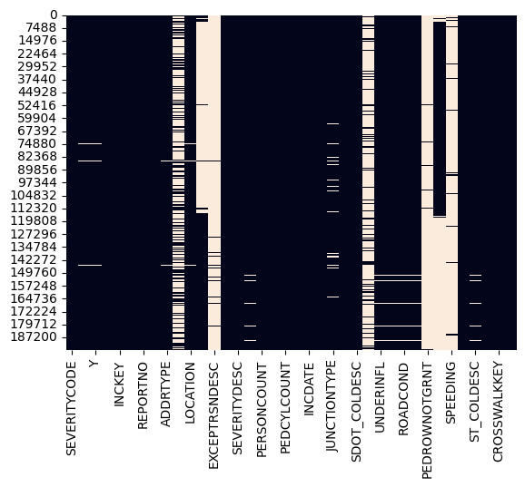

```python
sn.heatmap(raw_data.isnull(), cbar=False)
```

In addition, OBJECTID, INCKEY, COLDETKEY, and REPORTNO are unique identifiers for each record, therefore, they are deemed unfitting as features for machine learning models and can be discarded as well.

```python
# delete columns
data = raw_data.drop(columns=[col for col in empty_col if (raw_data[col].isnull().sum() / len(raw_data[col])) * 100 >= 80])
data = data.drop(columns=['OBJECTID', 'INCKEY', 'COLDETKEY', 'REPORTNO'])
data.head()
```

|  | SEVERITYCODE | X | Y | STATUS | ADDRTYPE | INTKEY | LOCATION | EXCEPTRSNCODE | SEVERITYCODE.1 | SEVERITYDESC | ... | UNDERINFL | WEATHER | ROADCOND | LIGHTCOND | SDOTCOLNUM | ST_COLCODE | ST_COLDESC | SEGLANEKEY | CROSSWALKKEY | HITPARKEDCAR |
| --- | --- | --- | --- | --- | --- | --- | --- | --- | --- | --- | --- | --- | --- | --- | --- | --- | --- | --- | --- | --- | --- |
| 0 | 2 | -122.323148 | 47.703140 | Matched | Intersection | 37475.0 | 5TH AVE NE AND NE 103RD ST |  | 2 | Injury Collision | ... | N | Overcast | Wet | Daylight | NaN | 10 | Entering at angle | 0 | 0 | N |
| 1 | 1 | -122.347294 | 47.647172 | Matched | Block | NaN | AURORA BR BETWEEN RAYE ST AND BRIDGE WAY N | NaN | 1 | Property Damage Only Collision | ... | 0 | Raining | Wet | Dark - Street Lights On | 6354039.0 | 11 | From same direction - both going straight - bo... | 0 | 0 | N |
| 2 | 1 | -122.334540 | 47.607871 | Matched | Block | NaN | 4TH AVE BETWEEN SENECA ST AND UNIVERSITY ST | NaN | 1 | Property Damage Only Collision | ... | 0 | Overcast | Dry | Daylight | 4323031.0 | 32 | One parked--one moving | 0 | 0 | N |
| 3 | 1 | -122.334803 | 47.604803 | Matched | Block | NaN | 2ND AVE BETWEEN MARION ST AND MADISON ST |  | 1 | Property Damage Only Collision | ... | N | Clear | Dry | Daylight | NaN | 23 | From same direction - all others | 0 | 0 | N |
| 4 | 2 | -122.306426 | 47.545739 | Matched | Intersection | 34387.0 | SWIFT AVE S AND SWIFT AV OFF RP | NaN | 2 | Injury Collision | ... | 0 | Raining | Wet | Daylight | 4028032.0 | 10 | Entering at angle | 0 | 0 | N |

5 rows × 30 columns

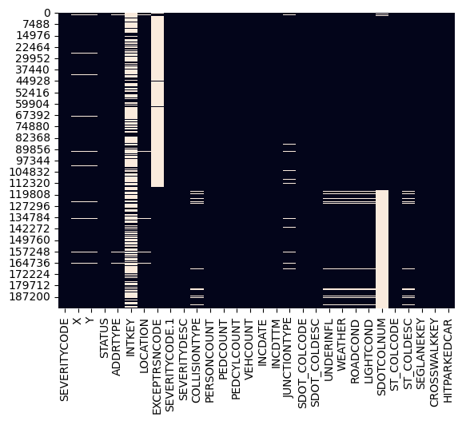

```python
sn.heatmap(data.isnull(), cbar=False)
```

Next, we can identify possible relations between existing variables. However, as a significant amount of them is categorical, it is necessary to encode the data for the interpretation. Noted that some columns require more cleansing, like the INCDTTM column, which represents the date and time of each incident. It is valuable for analysis but requires cleaning and standardization due to its unorganized format.

```python
# Assuming raw_data is your DataFrame and 'INCDTTM' is the column with dates and times
data['INCDTTM'] = pd.to_datetime(data['INCDTTM'], errors='coerce')

# Fill nulls with a default time or an indicator for missing time
data['TimeMissing'] = data['INCDTTM'].isnull()

# Extract features
data['Year'] = data['INCDTTM'].dt.year
data['Month'] = data['INCDTTM'].dt.month
data['Day'] = data['INCDTTM'].dt.day
data['DayOfWeek'] = data['INCDTTM'].dt.dayofweek
data['Hour'] = data['INCDTTM'].dt.hour
data['Minute'] = data['INCDTTM'].dt.minute


data
```

|  | SEVERITYCODE | X | Y | STATUS | ADDRTYPE | INTKEY | LOCATION | EXCEPTRSNCODE | SEVERITYCODE.1 | SEVERITYDESC | ... | SEGLANEKEY | CROSSWALKKEY | HITPARKEDCAR | TimeMissing | Year | Month | Day | DayOfWeek | Hour | Minute |
| --- | --- | --- | --- | --- | --- | --- | --- | --- | --- | --- | --- | --- | --- | --- | --- | --- | --- | --- | --- | --- | --- |
| 0 | 2 | -122.323148 | 47.703140 | Matched | Intersection | 37475.0 | 5TH AVE NE AND NE 103RD ST |  | 2 | Injury Collision | ... | 0 | 0 | N | False | 2013 | 3 | 27 | 2 | 14 | 54 |
| 1 | 1 | -122.347294 | 47.647172 | Matched | Block | NaN | AURORA BR BETWEEN RAYE ST AND BRIDGE WAY N | NaN | 1 | Property Damage Only Collision | ... | 0 | 0 | N | False | 2006 | 12 | 20 | 2 | 18 | 55 |
| 2 | 1 | -122.334540 | 47.607871 | Matched | Block | NaN | 4TH AVE BETWEEN SENECA ST AND UNIVERSITY ST | NaN | 1 | Property Damage Only Collision | ... | 0 | 0 | N | False | 2004 | 11 | 18 | 3 | 10 | 20 |
| 3 | 1 | -122.334803 | 47.604803 | Matched | Block | NaN | 2ND AVE BETWEEN MARION ST AND MADISON ST |  | 1 | Property Damage Only Collision | ... | 0 | 0 | N | False | 2013 | 3 | 29 | 4 | 9 | 26 |
| 4 | 2 | -122.306426 | 47.545739 | Matched | Intersection | 34387.0 | SWIFT AVE S AND SWIFT AV OFF RP | NaN | 2 | Injury Collision | ... | 0 | 0 | N | False | 2004 | 1 | 28 | 2 | 8 | 4 |
| ... | ... | ... | ... | ... | ... | ... | ... | ... | ... | ... | ... | ... | ... | ... | ... | ... | ... | ... | ... | ... | ... |
| 194668 | 2 | -122.290826 | 47.565408 | Matched | Block | NaN | 34TH AVE S BETWEEN S DAKOTA ST AND S GENESEE ST |  | 2 | Injury Collision | ... | 0 | 0 | N | False | 2018 | 11 | 12 | 0 | 8 | 12 |
| 194669 | 1 | -122.344526 | 47.690924 | Matched | Block | NaN | AURORA AVE N BETWEEN N 85TH ST AND N 86TH ST |  | 1 | Property Damage Only Collision | ... | 0 | 0 | N | False | 2018 | 12 | 18 | 1 | 9 | 14 |
| 194670 | 2 | -122.306689 | 47.683047 | Matched | Intersection | 24760.0 | 20TH AVE NE AND NE 75TH ST |  | 2 | Injury Collision | ... | 0 | 0 | N | False | 2019 | 1 | 19 | 5 | 9 | 25 |
| 194671 | 2 | -122.355317 | 47.678734 | Matched | Intersection | 24349.0 | GREENWOOD AVE N AND N 68TH ST |  | 2 | Injury Collision | ... | 4308 | 0 | N | False | 2019 | 1 | 15 | 1 | 16 | 48 |
| 194672 | 1 | -122.289360 | 47.611017 | Matched | Block | NaN | 34TH AVE BETWEEN E MARION ST AND E SPRING ST |  | 1 | Property Damage Only Collision | ... | 0 | 0 | N | False | 2018 | 11 | 30 | 4 | 15 | 45 |

194673 rows × 37 columns

Next, we can look into the target variable and its distribution:

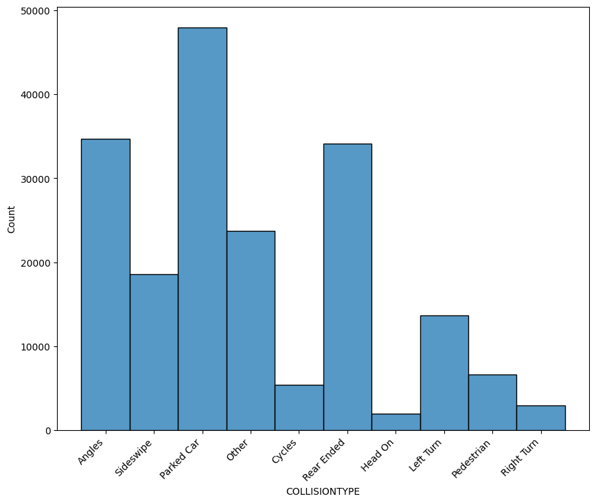

```python
# Plot the histogram
sn.histplot(raw_data['COLLISIONTYPE'])

# Rotate the x-axis labels for better readability
plt.xticks(rotation=45, ha='right')  # Rotate labels and align right for better space management

# Optional: Adjust the figure size if needed
plt.gcf().set_size_inches(10, 8)  # Set the figure size (width, height) in inches

# Display the plot
plt.show()
```

On the other end of the spectrum, 'Cycles', 'Head On', 'Pedestrian', and 'Right Turn' represent less frequent collision types, with 'Right Turn' and 'Head On' being the least common among the categories shown.

### ANOVA

To identify the most relevant features for our predictive modeling task, we are conducting statistical tests on our dataset. Our goal is to determine which variables significantly impact the target variable, COLLISIONTYPE. This process involves two key statistical methods: ANOVA for numerical independent variables and the Chi-squared test for categorical variables. By identifying significant variables, we aim to refine our feature selection, ensuring that our model includes variables that are truly influential in predicting collision types.

```python
from scipy import stats

# ANOVA test for numerical variables
for column in data.columns:
    if data[column].dtype in ['int64', 'float64']:
        groups = data.groupby('COLLISIONTYPE')[column].apply(list)
        F, p = stats.f_oneway(*groups)
        print(f"ANOVA F-value for {column} and target variable: {F}, p-value: {p}")
```

```
ANOVA F-value for SEVERITYCODE and target variable: 5824.9472362376155, p-value: 0.0
ANOVA F-value for X and target variable: nan, p-value: nan
ANOVA F-value for Y and target variable: nan, p-value: nan
ANOVA F-value for INTKEY and target variable: nan, p-value: nan
ANOVA F-value for SEVERITYCODE.1 and target variable: 5824.9472362376155, p-value: 0.0
ANOVA F-value for PERSONCOUNT and target variable: 1468.029314864942, p-value: 0.0
ANOVA F-value for PEDCOUNT and target variable: 181614.94238039383, p-value: 0.0
ANOVA F-value for PEDCYLCOUNT and target variable: 952237.4129443335, p-value: 0.0
ANOVA F-value for VEHCOUNT and target variable: 12756.995060313715, p-value: 0.0
ANOVA F-value for SDOT_COLCODE and target variable: 14242.597198065716, p-value: 0.0
ANOVA F-value for SDOTCOLNUM and target variable: nan, p-value: nan
ANOVA F-value for SEGLANEKEY and target variable: 5506.707171492261, p-value: 0.0
ANOVA F-value for CROSSWALKKEY and target variable: 12052.122016101957, p-value: 0.0
```

Our ANOVA results reveal that most numerical variables significantly impact the target variable, indicated by low (or zero) p-values. However, some variables returned NaN values, likely due to missing values, insufficient data in categories, or extremely low variance. To address these issues, we recommend handling missing values, filtering data for sufficient variance, and ensuring data distribution aligns with ANOVA assumptions. Rerunning ANOVA post these adjustments will yield more reliable results.

### Chi-squared test

For categorical independent variables, we employed the Chi-squared test to assess their association with the target variable COLLISIONTYPE. This test evaluates whether the distribution of occurrences of each category within these variables is independent of the collision types. Variables with high Chi-squared values and low p-values demonstrate a strong association with the target variable.

```python
import pandas as pd
from scipy.stats import chi2_contingency

# Loop through each categorical variable
for column in data.columns:
    # Check if the variable is categorical
    if data[column].dtype == 'object':
        # Create a contingency table
        contingency_table = pd.crosstab(data[column], data['COLLISIONTYPE'])

        # Perform the Chi-squared test
        chi2, p, dof, expected = chi2_contingency(contingency_table)

        # Print the results
        print(f"Chi-squared test for {column} and COLLISIONTYPE:")
        print(f"Chi-squared value: {chi2}, p-value: {p}")

        # Optional: Add a condition to print significant results
        if p < 0.05:
            print(f"{column} is significantly associated with COLLISIONTYPE.")
        else:
            print(f"No significant association found between {column} and COLLISIONTYPE.")
```

```
Chi-squared test for STATUS and COLLISIONTYPE:
Chi-squared value: 8.109437605903551, p-value: 0.5231563365382554
No significant association found between STATUS and COLLISIONTYPE.
```

```
Chi-squared test for ADDRTYPE and COLLISIONTYPE:
Chi-squared value: 92623.09642089902, p-value: 0.0
ADDRTYPE is significantly associated with COLLISIONTYPE.
Chi-squared test for LOCATION and COLLISIONTYPE:
Chi-squared value: 436013.2498169589, p-value: 0.0
LOCATION is significantly associated with COLLISIONTYPE.
Chi-squared test for EXCEPTRSNCODE and COLLISIONTYPE:
Chi-squared value: 5653.707022147728, p-value: 0.0
EXCEPTRSNCODE is significantly associated with COLLISIONTYPE.
Chi-squared test for SEVERITYDESC and COLLISIONTYPE:
Chi-squared value: 41078.556865008046, p-value: 0.0
SEVERITYDESC is significantly associated with COLLISIONTYPE.
Chi-squared test for COLLISIONTYPE and COLLISIONTYPE:
Chi-squared value: 1707921.0, p-value: 0.0
COLLISIONTYPE is significantly associated with COLLISIONTYPE.
Chi-squared test for INCDATE and COLLISIONTYPE:
Chi-squared value: 62558.659392439135, p-value: 1.2633243077226542e-151
INCDATE is significantly associated with COLLISIONTYPE.
Chi-squared test for JUNCTIONTYPE and COLLISIONTYPE:
Chi-squared value: 128008.57120085236, p-value: 0.0
JUNCTIONTYPE is significantly associated with COLLISIONTYPE.
Chi-squared test for SDOT_COLDESC and COLLISIONTYPE:
Chi-squared value: 604818.3818164463, p-value: 0.0
SDOT_COLDESC is significantly associated with COLLISIONTYPE.
Chi-squared test for UNDERINFL and COLLISIONTYPE:
Chi-squared value: 4608.660288162386, p-value: 0.0
UNDERINFL is significantly associated with COLLISIONTYPE.
Chi-squared test for WEATHER and COLLISIONTYPE:
Chi-squared value: 25191.11776541576, p-value: 0.0
WEATHER is significantly associated with COLLISIONTYPE.
Chi-squared test for ROADCOND and COLLISIONTYPE:
Chi-squared value: 26786.223164524323, p-value: 0.0
ROADCOND is significantly associated with COLLISIONTYPE.
Chi-squared test for LIGHTCOND and COLLISIONTYPE:
Chi-squared value: 28622.113314727678, p-value: 0.0
LIGHTCOND is significantly associated with COLLISIONTYPE.
Chi-squared test for ST_COLCODE and COLLISIONTYPE:
Chi-squared value: 1707921.0, p-value: 0.0
ST_COLCODE is significantly associated with COLLISIONTYPE.
Chi-squared test for ST_COLDESC and COLLISIONTYPE:
Chi-squared value: 1707921.0, p-value: 0.0
ST_COLDESC is significantly associated with COLLISIONTYPE.
Chi-squared test for HITPARKEDCAR and COLLISIONTYPE:
Chi-squared value: 19063.970940013216, p-value: 0.0
HITPARKEDCAR is significantly associated with COLLISIONTYPE.
```

The Chi-squared test results show a significant association between most categorical variables and COLLISIONTYPE, except for STATUS. High Chi-squared values and low p-values in variables like LOCATION, JUNCTIONTYPE, SDOT_COLDESC, and others suggest a strong relationship with the collision type. However, caution is needed as these associations do not imply causality, and variables directly related to COLLISIONTYPE (like ST_COLCODE and ST_COLDESC) may produce tautological results. A comprehensive analysis, considering aspects like multicollinearity and overall impact on the model, is essential. These insights will inform which variables to include in the model and which may require further analysis or transformation.

However, it's crucial to assess the balance of our categorical variables. An imbalanced categorical variable, where one or more classes dominate, might not contribute much predictive power and could potentially skew our model's performance. To quantify the balance, we'll calculate an "imbalance index" for each categorical variable. This index is the ratio of the smallest class frequency to the largest class frequency within each variable. Variables with an index close to 1 are balanced, while those closer to 0 are highly imbalanced. We will iterate through all categorical columns, compute their imbalance indices, and decide which variables might need special treatment or exclusion from our model.

```python
# Identify categorical columns in the DataFrame
categorical_cols = data.select_dtypes(include=['object', 'category']).columns

# Initialize a dictionary to store the imbalance index of each variable
imbalance_indices = {}

# Calculate the imbalance index for each categorical variable
for col in categorical_cols:
    # Get the proportion of each class within the column
    value_counts = data[col].value_counts(normalize=True)
    # Find the maximum and minimum proportion
    max_proportion = value_counts.max()
    min_proportion = value_counts.min()
    # Calculate the imbalance index as the ratio of min to max
    imbalance_index = min_proportion / max_proportion
    # Store the index in the dictionary
    imbalance_indices[col] = imbalance_index

# Output the imbalance index for each categorical variable
for col, index in imbalance_indices.items():
    print(f"Imbalance index for {col}: {index:.4f}")
```

```
Imbalance index for STATUS: 0.0258
Imbalance index for ADDRTYPE: 0.0059
Imbalance index for LOCATION: 0.0036
Imbalance index for EXCEPTRSNCODE: 0.0712
Imbalance index for SEVERITYDESC: 0.4263
Imbalance index for COLLISIONTYPE: 0.0422
Imbalance index for INCDATE: 0.0104
Imbalance index for JUNCTIONTYPE: 0.0001
Imbalance index for SDOT_COLDESC: 0.0000
Imbalance index for UNDERINFL: 0.0398
Imbalance index for WEATHER: 0.0000
Imbalance index for ROADCOND: 0.0005
Imbalance index for LIGHTCOND: 0.0001
Imbalance index for ST_COLCODE: 0.0000
Imbalance index for ST_COLDESC: 0.0000
Imbalance index for HITPARKEDCAR: 0.0385
```

```python
cols_to_keep = ['X', 'Y', 'STATUS', 'ADDRTYPE', 'SEVERITYDESC', 'COLLISIONTYPE',
                'PERSONCOUNT', 'PEDCOUNT', 'PEDCYLCOUNT', 'VEHCOUNT', 'JUNCTIONTYPE',
                'SDOT_COLDESC', 'WEATHER', 'ROADCOND', 'LIGHTCOND', 'ST_COLDESC',
                'Year', 'Month', 'Day', 'DayOfWeek', 'Hour', 'Minute']

# Dropping columns that are not in cols_to_keep
data = data[cols_to_keep]
data.dtypes
```

```
X                float64
Y                float64
STATUS            object
ADDRTYPE          object
SEVERITYDESC      object
COLLISIONTYPE     object
PERSONCOUNT        int64
PEDCOUNT           int64
PEDCYLCOUNT        int64
VEHCOUNT           int64
JUNCTIONTYPE      object
SDOT_COLDESC      object
WEATHER           object
ROADCOND          object
LIGHTCOND         object
ST_COLDESC        object
Year               int32
Month              int32
Day                int32
DayOfWeek          int32
Hour               int32
Minute             int32
dtype: object
```

### Imputation and encoding

To effectively prepare our dataset for the modeling stage, we will proceed to encode all categorical variables using a one-hot encoding scheme, with the exception of numerical and target features. This encoding will convert categorical entries into a series of binary columns, one for each category, which will enable our chosen machine learning algorithms to process the data without the need for inherent numerical value assignments.

```python
nan_dict, empty_col= {}, []
for col in cols_to_keep:
    if data[col].isnull().any():
        nan_dict[col] = round(((data[col].isnull().sum() / len(data[col])) * 100),2)
        empty_col.append(col)
nan_dict, empty_col
```

```
({'X': 2.74,
  'Y': 2.74,
  'ADDRTYPE': 0.99,
  'COLLISIONTYPE': 2.52,
  'JUNCTIONTYPE': 3.25,
  'WEATHER': 2.61,
  'ROADCOND': 2.57,
  'LIGHTCOND': 2.66,
  'ST_COLDESC': 2.52},
 ['X',
  'Y',
  'ADDRTYPE',
  'COLLISIONTYPE',
  'JUNCTIONTYPE',
  'WEATHER',
  'ROADCOND',
  'LIGHTCOND',
  'ST_COLDESC'])
```

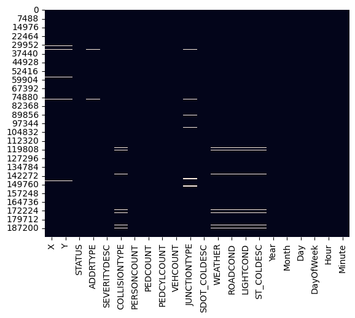

```python
sn.heatmap(data.isnull(), cbar=False)
```

### Imputer

Missing data can introduce bias and affect the model's performance. For numerical variables, we will apply Multiple Imputation by Chained Equations (MICE), a sophisticated technique that preserves the data structure and inherent relationships. For categorical variables, we will introduce a new 'Missing' category, which avoids the introduction of bias by imputing arbitrary modes or means and acknowledges the absence of data. This preparation ensures that our dataset is comprehensive and robust, enhancing the quality of the insights derived from our model. The MICE method is particularly suitable for large datasets like ours, where the relationships between variables can guide the imputation for a more accurate replacement of missing values.

[output not shown]

[output cut: 71 more lines]

[output not shown]

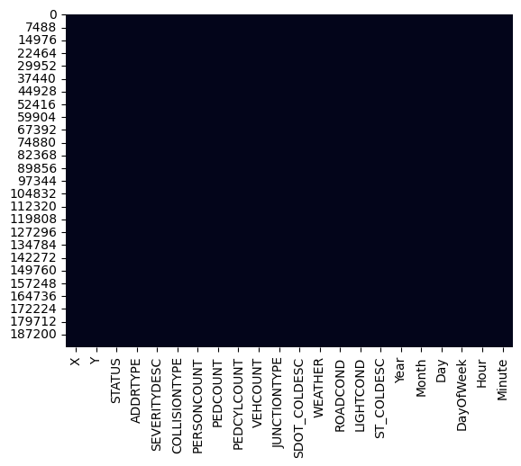

```python
from sklearn.experimental import enable_iterative_imputer
from sklearn.impute import IterativeImputer

numerical_cols = data.select_dtypes(include=['float64', 'int64']).columns

# MICE for Numerical Variables
mice_imputer = IterativeImputer()
data[numerical_cols] = mice_imputer.fit_transform(data[numerical_cols])

# 'Missing' Category for Categorical Variables
categorical_cols = data.select_dtypes(include=['object']).columns
for col in categorical_cols:
    data[col] = data[col].astype('category')
    data[col] = data[col].cat.add_categories('Missing').fillna('Missing')

# Check the heatmap again
sn.heatmap(data.isnull(), cbar=False)
plt.show()
```

### one-hot encoding

The next step in our data preprocessing is to transform the categorical variables into a format that can be provided to machine learning algorithms. We will use one-hot encoding, a process that converts categorical variables into a series of binary columns, with each representing a possible category value. This method is chosen because it enables the algorithms to better interpret and utilize the categorical data without assuming ordinal relationships where they might not exist. By maintaining the integrity of the original numerical and time-related columns while encoding the categorical ones, we create a comprehensive dataset ready for advanced analytical modeling

```python
# List of categorical columns to be one-hot encoded
# categorical_cols = ['STATUS', 'ADDRTYPE', 'JUNCTIONTYPE', 'SDOT_COLDESC', 'WEATHER', 'ROADCOND', 'LIGHTCOND']
data_for_encoding = data.drop(['COLLISIONTYPE'], axis=1)
categorical_cols = data_for_encoding.select_dtypes(include=['object', 'category']).columns # Performing one-hot encoding
data_encoded = pd.get_dummies(data_for_encoding, columns=categorical_cols)

# Now 'data_encoded' has all the original numerical columns, the newly encoded categorical columns,
# and the original time-related columns.
```

```python
categorical_cols
```

```
Index(['STATUS', 'ADDRTYPE', 'SEVERITYDESC', 'JUNCTIONTYPE', 'SDOT_COLDESC',
       'WEATHER', 'ROADCOND', 'LIGHTCOND', 'ST_COLDESC'],
      dtype='object')
```

```python
print(data_encoded.dtypes.to_string())
```

```
X                                                                                                   float64
Y                                                                                                   float64
PERSONCOUNT                                                                                         float64
PEDCOUNT                                                                                            float64
PEDCYLCOUNT                                                                                         float64
VEHCOUNT                                                                                            float64
Year                                                                                                  int32
Month                                                                                                 int32
Day                                                                                                   int32
DayOfWeek                                                                                             int32
Hour                                                                                                  int32
Minute                                                                                                int32
STATUS_Matched                                                                                         bool
STATUS_Unmatched                                                                                       bool
STATUS_Missing                                                                                         bool
ADDRTYPE_Alley                                                                                         bool
ADDRTYPE_Block                                                                                         bool
ADDRTYPE_Intersection                                                                                  bool
ADDRTYPE_Missing                                                                                       bool
SEVERITYDESC_Injury Collision                                                                          bool
SEVERITYDESC_Property Damage Only Collision                                                            bool
SEVERITYDESC_Missing                                                                                   bool
JUNCTIONTYPE_At Intersection (but not related to intersection)                                         bool
JUNCTIONTYPE_At Intersection (intersection related)                                                    bool
JUNCTIONTYPE_Driveway Junction                                                                         bool
JUNCTIONTYPE_Mid-Block (but intersection related)                                                      bool
JUNCTIONTYPE_Mid-Block (not related to intersection)                                                   bool
JUNCTIONTYPE_Ramp Junction                                                                             bool
JUNCTIONTYPE_Unknown                                                                                   bool
JUNCTIONTYPE_Missing                                                                                   bool
SDOT_COLDESC_DRIVERLESS VEHICLE RAN OFF ROAD - HIT FIXED OBJECT                                        bool
SDOT_COLDESC_DRIVERLESS VEHICLE RAN OFF ROAD - NO COLLISION                                            bool
SDOT_COLDESC_DRIVERLESS VEHICLE STRUCK MOTOR VEHICLE FRONT END AT ANGLE                                bool
SDOT_COLDESC_DRIVERLESS VEHICLE STRUCK MOTOR VEHICLE LEFT SIDE AT ANGLE                                bool
SDOT_COLDESC_DRIVERLESS VEHICLE STRUCK MOTOR VEHICLE LEFT SIDE SIDESWIPE                               bool
SDOT_COLDESC_DRIVERLESS VEHICLE STRUCK MOTOR VEHICLE REAR END                                          bool
SDOT_COLDESC_DRIVERLESS VEHICLE STRUCK MOTOR VEHICLE RIGHT SIDE AT ANGLE                               bool
SDOT_COLDESC_DRIVERLESS VEHICLE STRUCK MOTOR VEHICLE RIGHT SIDE SIDESWIPE                              bool
SDOT_COLDESC_DRIVERLESS VEHICLE STRUCK OBJECT IN ROADWAY                                               bool
SDOT_COLDESC_DRIVERLESS VEHICLE STRUCK PEDESTRIAN                                                      bool
```

[output cut: 110 more lines]

```
ST_COLDESC_Vehicle Hits Other Road or Construction Machinery                                           bool
ST_COLDESC_Vehicle Hits State Road or Construction Machinery                                           bool
ST_COLDESC_Vehicle Strikes All Other Non-Domestic Animal                                               bool
ST_COLDESC_Vehicle Strikes Deer                                                                        bool
ST_COLDESC_Vehicle Strikes Pedalcyclist                                                                bool
ST_COLDESC_Vehicle Strikes Railway Vehicle                                                             bool
ST_COLDESC_Vehicle Struck by City Road or Construction Machinery                                       bool
ST_COLDESC_Vehicle Struck by Other Road or Construction Machinery                                      bool
ST_COLDESC_Vehicle backing hits pedestrian                                                             bool
ST_COLDESC_Vehicle going straight hits pedestrian                                                      bool
ST_COLDESC_Vehicle hits Pedestrian - All Other Actions                                                 bool
ST_COLDESC_Vehicle overturned                                                                          bool
ST_COLDESC_Vehicle turning left hits pedestrian                                                        bool
ST_COLDESC_Vehicle turning right hits pedestrian                                                       bool
ST_COLDESC_Missing                                                                                     bool
```

```python
year_counts = data_encoded.groupby('Year').size()
year_counts
```

```
Year
2004    11865
2005    15115
2006    15188
2007    14456
2008    13660
2009    11734
2010    10808
2011    10919
2012    10907
2013    10577
2014    11841
2015    12995
2016    11659
2017    10873
2018    10419
2019     9412
2020     2245
dtype: int64
```

Because we have time frame data, we can split dataset based on years, keeping chronological order intact. We are aiming on 80/20 split (train/test).

```python
# dictionary of years and number of observations
d = dict(year_counts)

total_values = sum(d.values())

# New dictionary with the shares
year_fractions = {year: (count / total_values * 100) for year, count in d.items()}
year_fractions
```

```
{2004: 6.094835955679525,
 2005: 7.764302188798652,
 2006: 7.8018009688040975,
 2007: 7.425785804913882,
 2008: 7.016894998279167,
 2009: 6.027543624436876,
 2010: 5.551874168477395,
 2011: 5.608892861362387,
 2012: 5.602728678347794,
 2013: 5.433213645446466,
 2014: 6.082507589650336,
 2015: 6.6752965228870975,
 2016: 5.989017480595665,
 2017: 5.585263493139777,
 2018: 5.352051902420983,
 2019: 4.834774211112994,
 2020: 1.1532159056469053}
```

```python
from sklearn.preprocessing import LabelEncoder

label_encoder = LabelEncoder()

X = data_encoded

y = data["COLLISIONTYPE"]

y_encoded = label_encoder.fit_transform(data["COLLISIONTYPE"])
```

For the split we take all the observations up to 2015 for the training and the rest - for the training, keeping 80/20 division.

```python
# Split the data
train_indices = data_encoded[data_encoded['Year'] <= 2015].index
test_indices = data_encoded[data_encoded['Year'] >= 2016].index

X_train = X.loc[train_indices]
X_test = X.loc[test_indices]


y_train_encoded = y_encoded[train_indices]
y_test_encoded = y_encoded[test_indices]
```

### Correlation

Before delving into modeling, it's useful to visualize the correlation matrix of the encoded dataset to identify any potential relationships or multicollinearity between features. This heatmap of the correlation matrix provides insights into how each variable may relate to others. For instance, highly correlated variables can affect the performance and interpretability of some models, especially linear ones like logistic regression, due to multicollinearity.

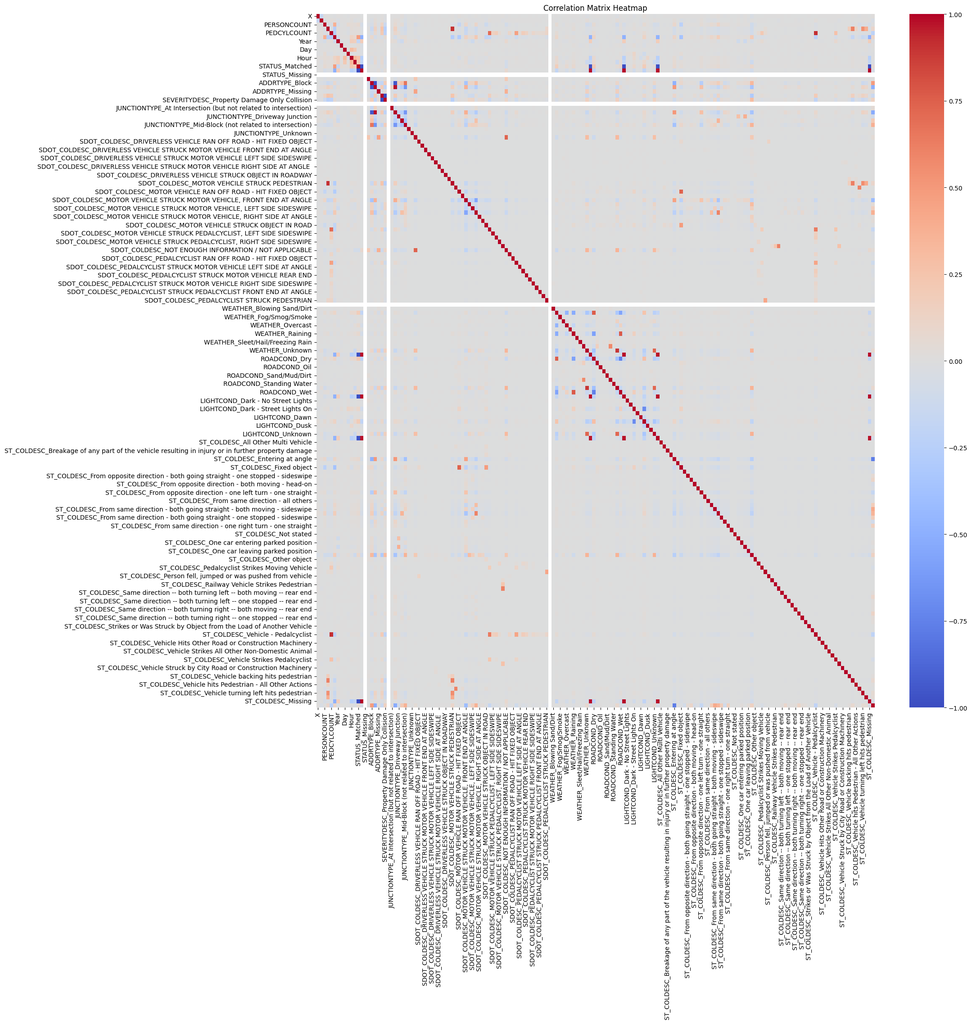

```python
# Ensure y_encoded is a DataFrame with appropriate column name
y_encoded_df = pd.DataFrame(y_encoded, columns=['Encoded_COLLISIONTYPE'])

# Concatenate X and y_encoded_df
data_encoded = pd.concat([X, y_encoded_df], axis=1)

# Now you can calculate the correlation matrix
correlation_matrix = data_encoded.corr()

# Plot the heatmap
plt.figure(figsize=(20, 20))
sn.heatmap(correlation_matrix, annot=False, cmap='coolwarm')
plt.title('Correlation Matrix Heatmap')
plt.show()
```

```python
correlation_matrix
```

|  | X | Y | PERSONCOUNT | PEDCOUNT | PEDCYLCOUNT | VEHCOUNT | Year | Month | Day | DayOfWeek | ... | ST_COLDESC_Vehicle Struck by City Road or Construction Machinery | ST_COLDESC_Vehicle Struck by Other Road or Construction Machinery | ST_COLDESC_Vehicle backing hits pedestrian | ST_COLDESC_Vehicle going straight hits pedestrian | ST_COLDESC_Vehicle hits Pedestrian - All Other Actions | ST_COLDESC_Vehicle overturned | ST_COLDESC_Vehicle turning left hits pedestrian | ST_COLDESC_Vehicle turning right hits pedestrian | ST_COLDESC_Missing | Encoded_COLLISIONTYPE |
| --- | --- | --- | --- | --- | --- | --- | --- | --- | --- | --- | --- | --- | --- | --- | --- | --- | --- | --- | --- | --- | --- |
| X | 1.000000 | -0.160266 | 0.012918 | 0.011372 | -0.001717 | -0.012151 | 0.010458 | 0.000213 | -0.003768 | -0.008339 | ... | 0.001976 | -0.001399 | -0.001616 | 0.010050 | 0.002993 | -0.011520 | 0.003621 | 0.007342 | -0.002769 | 0.008911 |
| Y | -0.160266 | 1.000000 | -0.013635 | 0.010253 | 0.026415 | 0.017628 | -0.025503 | 0.006457 | 0.002284 | -0.005620 | ... | -0.004095 | -0.000719 | -0.001713 | 0.002829 | -0.001152 | -0.003228 | 0.006033 | 0.014218 | 0.000785 | -0.039693 |
| PERSONCOUNT | 0.012918 | -0.013635 | 1.000000 | -0.023464 | -0.038809 | 0.380523 | -0.064019 | -0.000646 | 0.001211 | 0.058063 | ... | -0.004513 | -0.002245 | -0.003936 | -0.018198 | -0.003730 | -0.056166 | -0.024818 | -0.022068 | -0.067402 | 0.002463 |
| PEDCOUNT | 0.011372 | 0.010253 | -0.023464 | 1.000000 | -0.016920 | -0.261285 | 0.024348 | 0.005682 | 0.004522 | -0.019643 | ... | -0.001409 | -0.001274 | 0.176742 | 0.614557 | 0.116066 | -0.012153 | 0.544485 | 0.395766 | -0.030130 | 0.098621 |
| PEDCYLCOUNT | -0.001717 | 0.026415 | -0.038809 | -0.016920 | 1.000000 | -0.253773 | 0.034281 | 0.006844 | -0.001309 | -0.024964 | ... | -0.001275 | -0.001153 | -0.005908 | -0.019773 | -0.004051 | -0.009095 | -0.018039 | -0.013362 | -0.024129 | -0.223215 |
| ... | ... | ... | ... | ... | ... | ... | ... | ... | ... | ... | ... | ... | ... | ... | ... | ... | ... | ... | ... | ... | ... |
| ST_COLDESC_Vehicle overturned | -0.011520 | -0.003228 | -0.056166 | -0.012153 | -0.009095 | -0.077841 | -0.007934 | 0.000902 | -0.001777 | 0.003185 | ... | -0.000487 | -0.000441 | -0.002259 | -0.007948 | -0.001549 | 1.000000 | -0.006897 | -0.005109 | -0.010423 | -0.003706 |
| ST_COLDESC_Vehicle turning left hits pedestrian | 0.003621 | 0.006033 | -0.024818 | 0.544485 | -0.018039 | -0.154821 | 0.020907 | 0.004350 | -0.000608 | -0.018288 | ... | -0.000800 | -0.000723 | -0.003706 | -0.013039 | -0.002541 | -0.006897 | 1.000000 | -0.008381 | -0.017099 | 0.061681 |
| ST_COLDESC_Vehicle turning right hits pedestrian | 0.007342 | 0.014218 | -0.022068 | 0.395766 | -0.013362 | -0.114547 | 0.007638 | 0.001045 | 0.004406 | -0.015309 | ... | -0.000592 | -0.000536 | -0.002745 | -0.009658 | -0.001882 | -0.005109 | -0.008381 | 1.000000 | -0.012666 | 0.045687 |
| ST_COLDESC_Missing | -0.002769 | 0.000785 | -0.067402 | -0.030130 | -0.024129 | -0.488007 | 0.182709 | -0.033939 | -0.018197 | -0.015976 | ... | -0.001208 | -0.001093 | -0.005601 | -0.019706 | -0.003840 | -0.010423 | -0.017099 | -0.012666 | 1.000000 | -0.060389 |
| Encoded_COLLISIONTYPE | 0.008911 | -0.039693 | 0.002463 | 0.098621 | -0.223215 | 0.110903 | -0.032404 | 0.010868 | -0.001407 | -0.012759 | ... | -0.000430 | -0.000389 | 0.020202 | 0.071083 | 0.013851 | -0.003706 | 0.061681 | 0.045687 | -0.060389 | 1.000000 |

166 rows × 166 columns

```python
data_encoded.shape[1]
```

```
166
```

From the heatmap, we observe that there are certain blocks of high correlation, which are likely the one-hot encoded variables that represent the same categorical feature. The majority of the matrix shows low correlation between different features, which suggests that our features are mostly independent of each other, a condition that logistic regression models favor.

The diagonal line of perfect correlation represents each variable's relationship with itself. It's also apparent that some variables have a stronger relationship with the 'Encoded_COLLISIONTYPE', which are potential predictors for the outcome variable in the logistic regression model.

## Statistical tools

### Logistic regression

As our target data is categorical, we're utilizing logistic regression, which is particularly effective for multi-class classification problems. Our model is set to the 'multinomial' option, making it well-suited for predicting several classes. We've also chosen the 'lbfgs' solver for optimization due to its robustness in handling multi-class cases and set a high number of maximum iterations to ensure adequate convergence (limited 1000 iterations, because of time consumption). Once the model is trained, we'll not only predict the class labels but also compute the probabilities for each class, which can provide more nuanced insights into the model's confidence in its predictions. These probabilities can be especially helpful in decision-making processes where the degree of certainty is crucial.

```python
from sklearn.linear_model import LogisticRegression
from sklearn.metrics import classification_report, accuracy_score


# Create and fit the logistic regression model
model = LogisticRegression(multi_class='multinomial', solver='lbfgs', max_iter=1000)
model.fit(X_train, y_train_encoded)

# Predict on the test set
y_pred_encoded = model.predict(X_test)
y_pred_probabilities = model.predict_proba(X_test)
# predicted_labels = label_encoder.inverse_transform(y_pred_encoded)

# Decode the predictions back to original labels for evaluation
y_pred = label_encoder.inverse_transform(y_pred_encoded)
y_test = label_encoder.inverse_transform(y_test_encoded)



# Evaluate the model
print("Classification Report:\n", classification_report(y_test, y_pred))
print("Accuracy:", accuracy_score(y_test, y_pred))

# Show the probability of the first 5 predictions
# print("Predicted labels for the first 5 instances:\n", predicted_labels[:5])
print("Predicted probabilities for the first 5 instances:\n", y_pred_probabilities[:5])
print("First 5 predictions:", y_pred[:5])
```

[output not shown]

[output cut: 131 more lines]

[output not shown]

### Challenging Categories

Overall, while the model shows good predictive ability for certain collision types, there is room for improvement, crossvalidation and scaling can be beneficial for the comparison.

Same original model with scale implementation.

```python
from sklearn.linear_model import LogisticRegression
from sklearn.preprocessing import  StandardScaler
from sklearn.metrics import classification_report, accuracy_score
from sklearn.pipeline import Pipeline

# Create a pipeline with a scaler and logistic regression model
pipeline = Pipeline([
    ('scaler', StandardScaler()),
    ('model', LogisticRegression(multi_class='multinomial', solver='lbfgs', max_iter=1000))
])

# Fit the pipeline on the training data
pipeline.fit(X_train, y_train_encoded)

# Predict on the test set
y_pred_encoded = pipeline.predict(X_test)
y_test = label_encoder.inverse_transform(y_test_encoded)
# predicted_labels = label_encoder.inverse_transform(y_pred_encoded)


# Decode the predictions back to original labels for evaluation
y_pred = label_encoder.inverse_transform(y_pred_encoded)

# Evaluate the model
print("Classification Report:\n", classification_report(y_test, y_pred))
print("Accuracy:", accuracy_score(y_test, y_pred))

# Show the probability of the first 5 predictions
# print("Predicted labels for the first 5 instances:\n", predicted_labels[:5])
print("Predicted probabilities for the first 5 instances:\n", y_pred_probabilities[:5])
print("First 5 predictions:", y_pred[:5])
```

```
Classification Report:
               precision    recall  f1-score   support

      Angles       1.00      1.00      1.00      8622
      Cycles       0.99      0.98      0.99      1452
     Head On       1.00      1.00      1.00       520
   Left Turn       1.00      1.00      1.00      3106
     Missing       1.00      0.99      1.00      3255
       Other       1.00      1.00      1.00      4668
  Parked Car       1.00      1.00      1.00      8279
  Pedestrian       1.00      1.00      1.00      1829
  Rear Ended       1.00      1.00      1.00      7609
  Right Turn       1.00      1.00      1.00       698
   Sideswipe       1.00      1.00      1.00      4570

    accuracy                           1.00     44608
   macro avg       1.00      1.00      1.00     44608
weighted avg       1.00      1.00      1.00     44608

Accuracy: 0.9986101147776184
Predicted probabilities for the first 5 instances:
 [[9.86479166e-001 2.07866134e-004 2.39982441e-004 8.96711279e-003
  2.30288531e-135 2.95134105e-004 5.99235143e-007 2.24017196e-004
  5.07236813e-007 1.64637114e-003 1.93924344e-003]
 [8.68600602e-002 2.98542905e-001 1.55802952e-002 3.48599277e-001
  2.93140400e-147 9.05097779e-003 3.11675058e-007 1.33798599e-001
  2.25382226e-003 8.09603488e-002 2.43534036e-002]
 [6.96580196e-009 3.59575631e-003 8.59462930e-006 2.52941515e-006
  8.79269480e-001 1.14532993e-001 8.38997945e-006 2.51551177e-003
  6.87433186e-008 3.48929851e-005 3.17763277e-005]
 [3.14719456e-008 5.08088063e-006 1.51425196e-005 1.03453840e-005
  9.01109388e-139 2.73230022e-007 3.81720815e-006 3.64627484e-006
  9.99784667e-001 3.79040674e-005 1.39091505e-004]
 [2.53302092e-006 6.65958928e-001 1.42237358e-003 1.20724914e-003
  9.90919973e-117 2.01268947e-001 7.99036162e-004 1.02759861e-001
  1.10185510e-003 6.05616050e-003 1.94230562e-002]]
First 5 predictions: ['Angles' 'Cycles' 'Missing' 'Rear Ended' 'Cycles']
```

The scaled logistic regression model shows an exceptionally high accuracy of approximately 99.86% on the test dataset. This level of performance, while impressive, suggests potential overfitting. It's crucial for us to validate the model further, possibly using cross-validation or a separate validation set, to ensure it generalizes well to new data. We should also review the model's complexity and the features used to avoid data leakage and ensure the model's practical applicability. Testing on an entirely new dataset might provide a more accurate assessment of the model's effectiveness. Our goal is to balance model accuracy with its ability to generalize.

### Non-scaled vs scaled model

On the other hand, the model with scaling demonstrated an almost perfect accuracy of about 99.86%. While this high accuracy initially appears favorable, it raises concerns about overfitting. Such a high level of accuracy is unusual in real-world datasets and suggests that the model might not generalize well to unseen data. This could be a result of the scaling process, which might have amplified certain features' influence, leading to an over-optimized model on the training data.

### Cross-validation

We can retest model, using cross-validation. For implementing cross-validation on the logistic regression model, we use Scikit-learn's cross_val_score function. This will provide a more robust evaluation by splitting the dataset into multiple folds and assessing the model on each fold. Next code will perform 5-fold cross-validation on our dataset, increased number of iterations (2000) and return the accuracy for each fold. This process is very time demanding - to solve this, we will use only sample of the data (up to 2015).

```python
from sklearn.linear_model import LogisticRegression
from sklearn.model_selection import cross_val_score

# Forming sample for the validation
time_split_year = 2015

X_sample = X[X['Year'] <= time_split_year]
y_sample = y_encoded[X['Year'] <= time_split_year]

# Create a logistic regression model with a higher number of iterations
model = LogisticRegression(multi_class='multinomial', solver='lbfgs', max_iter=2000)

# Perform cross-validation
scores = cross_val_score(model, X_sample, y_sample, cv=5, scoring='accuracy', n_jobs=-1)

# Output the results of cross-validation
print("Cross-Validation Accuracy Scores:", scores)
print("Mean CV Accuracy:", scores.mean())
```

```
Cross-Validation Accuracy Scores: [0.92829774 0.91953487 0.92319995 0.91177157 0.91433712]
Mean CV Accuracy: 0.9194282477593043
```

After performing cross-validation on the logistic regression model, focusing on the data up to the year 2015, we observed the following:

- The cross-validation process was carried out with multi_class='multinomial' and max_iter=2000 settings on the logistic regression model.
- The accuracy scores across the 5 folds were consistently high, showcasing the model's stable performance. The scores were as follows: [0.92829774, 0.91953487, 0.92319995, 0.91177157, 0.91433712].
- The mean cross-validation accuracy was approximately 91.94%, indicating that the model has a strong predictive ability on the data sampled for validation.

We can use new infromation for the improvement of the model. First, we will increase number of iterations to 2000.

```python
from sklearn.linear_model import LogisticRegression
from sklearn.metrics import classification_report, accuracy_score


# Create and fit the logistic regression model
model = LogisticRegression(multi_class='multinomial', solver='lbfgs', max_iter=2000)
model.fit(X_train, y_train_encoded)

# Predict on the test set
y_pred_encoded = model.predict(X_test)
y_pred_probabilities = model.predict_proba(X_test)
# predicted_labels = label_encoder.inverse_transform(y_pred_encoded)

# Decode the predictions back to original labels for evaluation
y_pred = label_encoder.inverse_transform(y_pred_encoded)
y_test = label_encoder.inverse_transform(y_test_encoded)



# Evaluate the model
print("Classification Report:\n", classification_report(y_test, y_pred))
print("Accuracy:", accuracy_score(y_test, y_pred))

# Show the probability of the first 5 predictions
# print("Predicted labels for the first 5 instances:\n", predicted_labels[:5])
print("Predicted probabilities for the first 5 instances:\n", y_pred_probabilities[:5])
print("First 5 predictions:", y_pred[:5])
```

[output not shown]

```
Classification Report:
               precision    recall  f1-score   support

      Angles       0.94      0.94      0.94      8622
      Cycles       0.96      0.96      0.96      1452
     Head On       0.29      0.13      0.18       520
   Left Turn       0.83      0.84      0.83      3106
     Missing       1.00      0.99      0.99      3255
       Other       0.85      0.87      0.86      4668
  Parked Car       0.93      0.93      0.93      8279
  Pedestrian       0.98      0.97      0.98      1829
  Rear Ended       0.92      0.94      0.93      7609
  Right Turn       0.51      0.40      0.45       698
   Sideswipe       0.80      0.84      0.82      4570

    accuracy                           0.90     44608
   macro avg       0.82      0.80      0.81     44608
weighted avg       0.90      0.90      0.90     44608

Accuracy: 0.9003541965566715
Predicted probabilities for the first 5 instances:
 [[9.99970898e-001 1.85269242e-007 3.06422635e-007 2.08631111e-005
  4.85023415e-241 1.40070483e-007 4.80799224e-013 8.27099937e-008
  1.93594667e-012 5.64020646e-006 1.88384603e-006]
 [5.22334457e-003 9.16422365e-001 4.02754982e-004 2.73687733e-002
  3.90425687e-261 8.22252456e-004 1.98417618e-012 3.74430783e-002
  8.17180485e-007 1.08982021e-002 1.41841252e-003]
 [1.85234860e-013 3.39280487e-006 2.27398752e-006 3.86354842e-010
  9.98216513e-001 1.77625855e-003 9.70957797e-009 8.97037522e-007
  3.23895166e-011 2.37088141e-007 4.17716652e-007]
 [2.86999375e-011 4.29564875e-008 1.43480964e-006 3.17448436e-008
  2.25020093e-244 1.65861596e-008 4.51741079e-008 1.18178486e-008
  9.99994835e-001 2.30940241e-006 1.27268949e-006]
 [1.17678804e-008 8.71316853e-001 1.43470965e-002 1.71503658e-005
  6.43233029e-207 1.00913086e-001 1.98103834e-005 7.02361644e-003
  6.06706636e-005 2.41183997e-003 3.88986433e-003]]
First 5 predictions: ['Angles' 'Cycles' 'Missing' 'Rear Ended' 'Cycles']
```

### Hyperparameter tuning

We can try also tune the hyperparameter C and choose the best model in the end. (3 values to test: 0.1, 1, 10)

```python
from sklearn.linear_model import LogisticRegression
from sklearn.metrics import classification_report, accuracy_score

# Hyperparameter values to test
C_values = [0.1, 1, 10]

# iterations
for C_val in C_values:
    print(f"Testing model with C = {C_val}")

    # model training
    model = LogisticRegression(multi_class='multinomial', solver='lbfgs', C=C_val, max_iter=2000)
    model.fit(X_train, y_train_encoded)

    # predictions
    y_pred_encoded = model.predict(X_test)
    y_pred = label_encoder.inverse_transform(y_pred_encoded)
    y_test = label_encoder.inverse_transform(y_test_encoded)

    # model evaluation
    print("Accuracy:", accuracy_score(y_test, y_pred))
    print("Classification Report:\n", classification_report(y_test, y_pred))
    print("\n")
```

```
Testing model with C = 0.1
```

```
Accuracy: 0.9030667144906743
Classification Report:
               precision    recall  f1-score   support

      Angles       0.97      0.98      0.97      8622
      Cycles       0.97      0.94      0.96      1452
     Head On       0.70      0.01      0.03       520
   Left Turn       0.76      0.84      0.80      3106
     Missing       1.00      0.99      1.00      3255
       Other       0.83      0.86      0.85      4668
  Parked Car       0.93      0.93      0.93      8279
  Pedestrian       0.98      0.98      0.98      1829
  Rear Ended       0.86      0.96      0.91      7609
  Right Turn       0.85      0.12      0.21       698
   Sideswipe       0.87      0.82      0.84      4570

    accuracy                           0.90     44608
   macro avg       0.88      0.77      0.77     44608
weighted avg       0.90      0.90      0.89     44608



Testing model with C = 1
```

```
Accuracy: 0.9003541965566715
Classification Report:
               precision    recall  f1-score   support

      Angles       0.94      0.94      0.94      8622
      Cycles       0.96      0.96      0.96      1452
     Head On       0.29      0.13      0.18       520
   Left Turn       0.83      0.84      0.83      3106
     Missing       1.00      0.99      0.99      3255
       Other       0.85      0.87      0.86      4668
  Parked Car       0.93      0.93      0.93      8279
  Pedestrian       0.98      0.97      0.98      1829
  Rear Ended       0.92      0.94      0.93      7609
  Right Turn       0.51      0.40      0.45       698
   Sideswipe       0.80      0.84      0.82      4570

    accuracy                           0.90     44608
   macro avg       0.82      0.80      0.81     44608
weighted avg       0.90      0.90      0.90     44608



Testing model with C = 10
```

```
Accuracy: 0.9114732783357246
Classification Report:
               precision    recall  f1-score   support

      Angles       0.98      0.98      0.98      8622
      Cycles       0.95      0.93      0.94      1452
     Head On       0.76      0.17      0.28       520
   Left Turn       0.79      0.85      0.82      3106
     Missing       1.00      0.99      0.99      3255
       Other       0.86      0.85      0.86      4668
  Parked Car       0.93      0.93      0.93      8279
  Pedestrian       0.97      0.98      0.98      1829
  Rear Ended       0.88      0.95      0.91      7609
  Right Turn       0.80      0.48      0.60       698
   Sideswipe       0.86      0.85      0.86      4570

    accuracy                           0.91     44608
   macro avg       0.89      0.82      0.83     44608
weighted avg       0.91      0.91      0.91     44608
```

### Results Overview

1. **C = 0.1 (Strong Regularization)**
   - **Accuracy**: Approximately 90.31%.
   - **Observations**: Faced challenges in categories like 'Head On' and 'Right Turn'.
   - **Issue Noted**: Model did not converge, suggesting the need for more iterations or scaling.
2. **C = 1 (Default Regularization)**
   - **Accuracy**: Slightly lower, around 90.04%.
   - **Observations**: Similar performance to C=0.1 with a slight decrease in certain categories.
   - **Issue Noted**: Continued non-convergence, indicating potential adjustments needed.
3. **C = 10 (Weak Regularization)**
   - **Accuracy**: Improved to about 91.15%.
   - **Observations**: Enhanced performance in previously challenging categories.
   - **Issue Noted**: Convergence warning still present.

```python
# best model - without scaling
from sklearn.linear_model import LogisticRegression
from sklearn.metrics import classification_report, accuracy_score


# Create and fit the logistic regression model
model = LogisticRegression(multi_class='multinomial', solver='lbfgs', C=10, max_iter=2000)
model.fit(X_train, y_train_encoded)

# Predict on the test set
y_pred_encoded = model.predict(X_test)
y_pred_probabilities = model.predict_proba(X_test)
# predicted_labels = label_encoder.inverse_transform(y_pred_encoded)

# Decode the predictions back to original labels for evaluation
y_pred = label_encoder.inverse_transform(y_pred_encoded)
y_test = label_encoder.inverse_transform(y_test_encoded)



# Evaluate the model
print("Classification Report:\n", classification_report(y_test, y_pred))
print("Accuracy:", accuracy_score(y_test, y_pred))

# Show the probability of the first 5 predictions
# print("Predicted labels for the first 5 instances:\n", predicted_labels[:5])
print("Predicted probabilities for the first 5 instances:\n", y_pred_probabilities[:5])
print("First 5 predictions:", y_pred[:5])
```

[output not shown]

```
Classification Report:
               precision    recall  f1-score   support

      Angles       0.98      0.98      0.98      8622
      Cycles       0.95      0.93      0.94      1452
     Head On       0.76      0.17      0.28       520
   Left Turn       0.79      0.85      0.82      3106
     Missing       1.00      0.99      0.99      3255
       Other       0.86      0.85      0.86      4668
  Parked Car       0.93      0.93      0.93      8279
  Pedestrian       0.97      0.98      0.98      1829
  Rear Ended       0.88      0.95      0.91      7609
  Right Turn       0.80      0.48      0.60       698
   Sideswipe       0.86      0.85      0.86      4570

    accuracy                           0.91     44608
   macro avg       0.89      0.82      0.83     44608
weighted avg       0.91      0.91      0.91     44608

Accuracy: 0.9114732783357246
Predicted probabilities for the first 5 instances:
 [[9.96865160e-001 1.77878693e-005 1.57434929e-004 1.43145745e-003
  7.89431466e-142 5.48488964e-005 2.95704176e-008 2.02926506e-005
  1.66606862e-006 8.50213426e-004 6.01108679e-004]
 [8.68434922e-003 7.39752491e-001 1.26242217e-002 5.73902001e-002
  9.07181748e-154 1.54228547e-002 6.02395428e-007 7.23507049e-002
  5.22239578e-004 6.97016932e-002 2.35506434e-002]
 [1.78605144e-007 3.70392235e-005 1.61189752e-005 1.89932420e-007
  9.99350283e-001 5.64942461e-004 1.35812351e-006 1.19142579e-005
  1.17354260e-006 5.27652251e-006 1.15249424e-005]
 [6.56639571e-007 7.78470023e-006 7.21725022e-004 3.33715345e-005
  5.90984698e-144 1.32537673e-004 2.66431711e-004 7.30315832e-006
  9.97649160e-001 5.79237526e-004 6.01791960e-004]
 [1.14242642e-004 7.06678427e-001 6.36135887e-002 1.17990341e-003
  2.63269073e-121 1.04930748e-001 2.41802391e-003 2.34082305e-002
  2.79068614e-002 2.28137148e-002 4.69362604e-002]]
First 5 predictions: ['Angles' 'Cycles' 'Missing' 'Rear Ended' 'Cycles']
```

As we can see, we sacrificed time but improved the accuracy of the model by tuning. The results can be depicted in the confusion matrix as well.

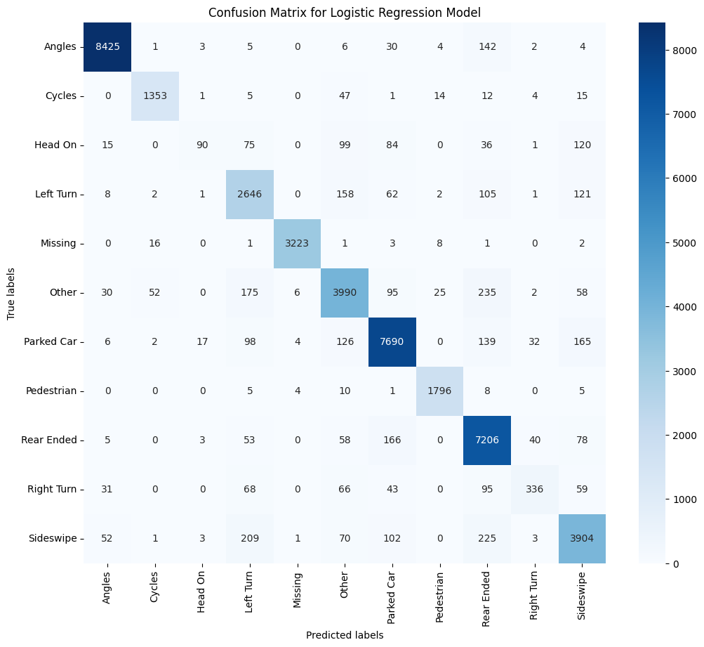

```python
from sklearn.metrics import confusion_matrix

# Confusion Matrix
cm = confusion_matrix(y_test, y_pred)
labels = np.unique(y_test)

# Plotting Confusion Matrix
plt.figure(figsize=(12, 10))
sn.heatmap(cm, annot=True, fmt='g', xticklabels=labels, yticklabels=labels, cmap='Blues')
plt.xlabel('Predicted labels')
plt.ylabel('True labels')
plt.title('Confusion Matrix for Logistic Regression Model')
plt.show()
```

## Predictive Tools

### Support Vector Machine (SVM)

We are now shifting our focus to the SVM model. SVM is renowned for its robustness and effectiveness, especially in high-dimensional spaces. This model is distinct for its use of a technique known as the kernel trick to transform data and find an optimal boundary between the possible outputs.

```python
from sklearn.svm import SVC
from sklearn.metrics import classification_report, accuracy_score

# Initializing the SVC model
svm_model = SVC(kernel='linear')  # we can change the kernel if needed

# Fitting the model to the training data
svm_model.fit(X_train, y_train_encoded)

# Predicting on the test set
y_pred_encoded = svm_model.predict(X_test)

y_pred = label_encoder.inverse_transform(y_pred_encoded)

# Evaluating the model
print("Classification Report:\n", classification_report(y_test, y_pred))
print("Accuracy:", accuracy_score(y_test, y_pred))

print("First 5 predictions:", y_pred[:5])
```

```
Classification Report:
               precision    recall  f1-score   support

      Angles       1.00      1.00      1.00      8622
      Cycles       1.00      0.51      0.67      1452
     Head On       1.00      1.00      1.00       520
   Left Turn       1.00      1.00      1.00      3106
     Missing       1.00      0.99      1.00      3255
       Other       0.86      1.00      0.93      4668
  Parked Car       1.00      1.00      1.00      8279
  Pedestrian       1.00      1.00      1.00      1829
  Rear Ended       1.00      1.00      1.00      7609
  Right Turn       1.00      1.00      1.00       698
   Sideswipe       1.00      1.00      1.00      4570

    accuracy                           0.98     44608
   macro avg       0.99      0.95      0.96     44608
weighted avg       0.99      0.98      0.98     44608

Accuracy: 0.9834110473457676
First 5 predictions: ['Angles' 'Other' 'Missing' 'Rear Ended' 'Other']
```

### Collision Type Performance

In summary, our SVM model with a linear kernel has demonstrated exceptional performance, showcasing high accuracy and precision across multiple collision types. However, it can be optimal to test the model by tuning the parameters through grid search.

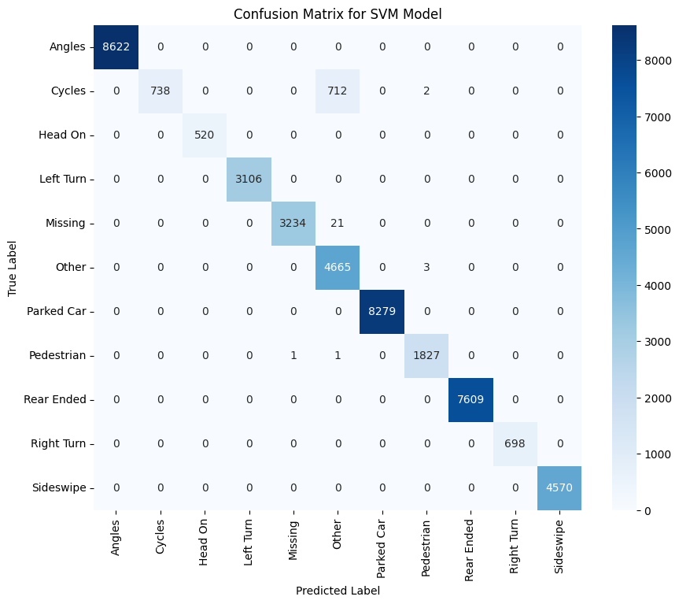

```python
from sklearn.metrics import confusion_matrix

cm = confusion_matrix(y_test, y_pred)

# Plotting the confusion matrix
plt.figure(figsize=(10, 8))
sn.heatmap(cm, annot=True, fmt='g', cmap='Blues', xticklabels=label_encoder.classes_, yticklabels=label_encoder.classes_)
plt.xlabel('Predicted Label')
plt.ylabel('True Label')
plt.title('Confusion Matrix for SVM Model')
plt.show()
```

### Grid search

```python
from sklearn.svm import SVC
from sklearn.model_selection import GridSearchCV

param_grid = {
    'C': [0.1, 1, 10],
}

svm = SVC()

grid_search = GridSearchCV(svm, param_grid, cv=5, scoring='accuracy', n_jobs=-1)

grid_search.fit(X_train, y_train_encoded)

# Print the best parameters and the corresponding score
print("Best parameters found:", grid_search.best_params_)
print("Best CV accuracy:", grid_search.best_score_)
```

[output not shown]

[output cut: 88 more lines]

```python
from sklearn.ensemble import RandomForestClassifier
from sklearn.metrics import classification_report, accuracy_score

# Initializing the Random Forest Classifier
# n_estimators defines the number of trees in the forest
random_forest = RandomForestClassifier(n_estimators=100, random_state=0)

# Fitting the model to the training data
random_forest.fit(X_train, y_train_encoded)

# Making predictions on the test set
y_pred = random_forest.predict(X_test)

# Decoding the predictions back to original labels for evaluation
y_pred_inv = label_encoder.inverse_transform(y_pred)

# Evaluating the model
print("Classification Report:\n", classification_report(y_test_encoded, y_pred))
print("Accuracy:", accuracy_score(y_test_encoded, y_pred))
print("First 5 predictions:", y_pred_inv[:5])

# Feature importance
feature_importances = random_forest.feature_importances_
print("Feature importances:\n", feature_importances)
```

[output not shown]

[output cut: 9 more lines]

[output not shown]

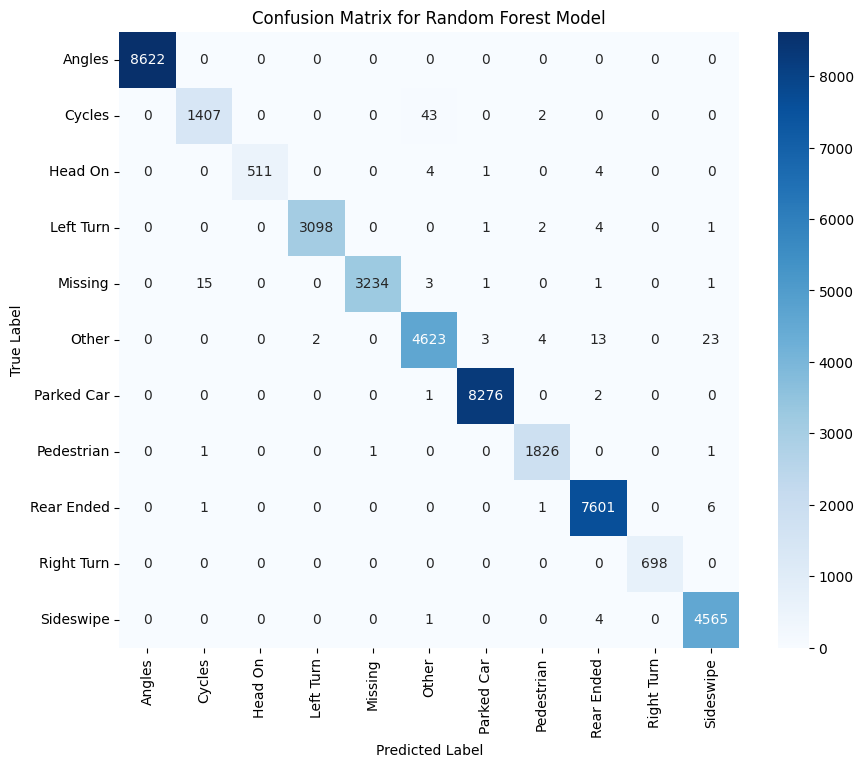

```python
from sklearn.metrics import confusion_matrix

# Calculating the confusion matrix
y_test_inv = label_encoder.inverse_transform(y_test_encoded)
cm = confusion_matrix(y_test_inv, y_pred_inv)

# Plotting the confusion matrix
plt.figure(figsize=(10, 8))
sn.heatmap(cm, annot=True, fmt='g', cmap='Blues', xticklabels=label_encoder.classes_, yticklabels=label_encoder.classes_)
plt.xlabel('Predicted Label')
plt.ylabel('True Label')
plt.title('Confusion Matrix for Random Forest Model')
plt.show()
```

```python
from sklearn.model_selection import cross_val_score

# Perform cross-validation
cv_scores = cross_val_score(random_forest, X_train, y_train_encoded, cv=5, scoring='accuracy')

# Output  of cross-validation
print("Cross-Validation Scores:", cv_scores)
print("Mean CV Score:", cv_scores.mean())
```

```
Cross-Validation Scores: [0.99883384 0.99900043 0.99900043 0.99873388 0.99883384]
Mean CV Score: 0.9988804851231133
```

- The scores across all five folds are extremely high (around 99.88%) and exhibit remarkable consistency. This indicates that the model is performing consistently well across different subsets of the training data.
- The high cross-validation scores suggest that the Random Forest model is generalizing very well. It's not just memorizing the training data but actually learning patterns that apply across different data subsets.
- Given the uniformity in the scores across folds, there's little evidence of overfitting. If overfitting were present, you would typically expect to see more variation in the model's performance across different folds.

### K-Nearest Neighbors (KNN) Model

We now turn our attention to the K-Nearest Neighbors (KNN) algorithm. KNN is a simple yet powerful machine learning technique that makes predictions based on the proximity of data points in feature space. This model is particularly known for its straightforward logic and ease of interpretation.

```python
from sklearn.neighbors import KNeighborsClassifier
from sklearn.metrics import classification_report, accuracy_score

# Initializing the KNN classifier
knn = KNeighborsClassifier(n_neighbors=5)  # We will start with 5 neighbors

# Fiting the model to the training data
knn.fit(X_train, y_train_encoded)

# predictions on the test set
y_pred_encoded = knn.predict(X_test)

# Decoding the predictions back to original labels for evaluation
y_pred = label_encoder.inverse_transform(y_pred_encoded)

# Evaluating the model
print("Classification Report:\n", classification_report(y_test, y_pred))
print("Accuracy:", accuracy_score(y_test, y_pred))
print("First 5 predictions:", y_pred[:5])
```

```
Classification Report:
               precision    recall  f1-score   support

      Angles       0.42      0.70      0.52      8622
      Cycles       0.38      0.15      0.22      1452
     Head On       0.03      0.01      0.01       520
   Left Turn       0.21      0.15      0.17      3106
     Missing       0.99      0.99      0.99      3255
       Other       0.47      0.26      0.33      4668
  Parked Car       0.43      0.63      0.51      8279
  Pedestrian       0.65      0.13      0.21      1829
  Rear Ended       0.50      0.43      0.46      7609
  Right Turn       0.08      0.01      0.01       698
   Sideswipe       0.27      0.14      0.19      4570

    accuracy                           0.46     44608
   macro avg       0.40      0.33      0.33     44608
weighted avg       0.45      0.46      0.43     44608

Accuracy: 0.4602986011477762
First 5 predictions: ['Left Turn' 'Rear Ended' 'Missing' 'Rear Ended' 'Rear Ended']
```

**Conclusion:**

- The KNN model, with its current configuration, shows limited effectiveness in accurately predicting several collision categories.
- The accuracy of 46.03% suggests that the model might be facing challenges due to the complexity of the dataset or the choice of k (number of neighbors).
- The KNN model's performance indicates a need for further tuning and possibly exploring different values of k or other feature engineering techniques.
- Comparison with the previous models (Logistic Regression and SVM) shows that KNN, in its current state, is less effective for this particular dataset. Further investigation and optimization might help improve the KNN model's ability to classify the data accurately.

The lower accuracy and inconsistent performance across categories suggest that the KNN model, in its current form, might be less suitable for this dataset and might benefit from parameter tuning, feature scaling, or exploring alternative algorithms.

### Grid search

We will explore k as a main parameter.

```python
from sklearn.neighbors import KNeighborsClassifier
from sklearn.model_selection import GridSearchCV
from sklearn.metrics import classification_report, accuracy_score

# Hyperparameter tuning for KNN
param_grid = {'n_neighbors': [2, 3, 5, 7, 9]}
knn = KNeighborsClassifier()
grid_search = GridSearchCV(knn, param_grid, cv=5)
grid_search.fit(X_train, y_train_encoded)

# Identify the best hyperparameter value
best_k = grid_search.best_params_['n_neighbors']
best_knn = KNeighborsClassifier(n_neighbors=best_k)

# Fit the model with the best hyperparameter
best_knn.fit(X_train, y_train_encoded)

# Predict on the test set
y_pred = best_knn.predict(X_test)
y_pred_inv = label_encoder.inverse_transform(y_pred)

# Model evaluation
print("Classification Report:\n", classification_report(y_test_encoded, y_pred))
print("Accuracy:", accuracy_score(y_test_encoded, y_pred))
print("First 5 predictions:", y_pred[:5])
print("First 5 predictions:", y_pred_inv[:5])
```

```
Classification Report:
               precision    recall  f1-score   support

           0       0.43      0.71      0.53      8622
           1       0.50      0.13      0.20      1452
           2       0.00      0.00      0.00       520
           3       0.20      0.10      0.14      3106
           4       0.99      0.99      0.99      3255
           5       0.49      0.25      0.33      4668
           6       0.41      0.67      0.51      8279
           7       0.71      0.09      0.16      1829
           8       0.51      0.46      0.49      7609
           9       0.00      0.00      0.00       698
          10       0.30      0.12      0.18      4570

    accuracy                           0.47     44608
   macro avg       0.41      0.32      0.32     44608
weighted avg       0.46      0.47      0.43     44608

Accuracy: 0.46679967718794835
First 5 predictions: [0 0 4 8 8]
```

- The grid search for hyperparameter tuning provided valuable insights into the optimal number of neighbors for the KNN model. However, the overall performance improvement is still insignificant.
- This outcome suggests that further exploration of other model configurations or different algorithms might be necessary to achieve better predictive performance.
- The results also highlight the importance of considering model complexity and the nature of the data when choosing the most suitable machine learning algorithm.

To further explore hyperparameter tuning for the K-Nearest Neighbors (KNN) model, we can extend our grid search to include additional hyperparameters beyond just the number of neighbors (n_neighbors). KNN has several other parameters that can significantly affect its performance, such as the weight function (weights) and the distance metric (metric).

```python
from sklearn.neighbors import KNeighborsClassifier
from sklearn.model_selection import GridSearchCV

# Extended hyperparameter grid
param_grid = {
    'n_neighbors': [5],  # fixed
    'weights': ['uniform', 'distance'],
    'metric': ['euclidean', 'manhattan']
}

# Initialize the KNN model
knn = KNeighborsClassifier()

# Create GridSearchCV with the KNN model and the extended hyperparameter grid
grid_search = GridSearchCV(knn, param_grid, cv=5, scoring='accuracy', n_jobs=-1)

# Fit GridSearchCV
grid_search.fit(X_train, y_train_encoded)

# Identify the best hyperparameter values
best_params = grid_search.best_params_
best_knn = KNeighborsClassifier(**best_params)

# Fit the model with the best hyperparameters
best_knn.fit(X_train, y_train_encoded)

# Predict on the test set
y_pred = best_knn.predict(X_test)
y_pred_inv = label_encoder.inverse_transform(y_pred)

# Model evaluation
print("Best Hyperparameters:", best_params)
print("Classification Report:\n", classification_report(y_test_encoded, y_pred))
print("Accuracy:", accuracy_score(y_test_encoded, y_pred))
print("First 5 predictions:", y_pred_inv[:5])
```

```
Best Hyperparameters: {'metric': 'manhattan', 'n_neighbors': 5, 'weights': 'distance'}
Classification Report:
               precision    recall  f1-score   support

           0       0.67      0.89      0.77      8622
           1       0.95      0.70      0.81      1452
           2       0.17      0.02      0.04       520
           3       0.66      0.44      0.53      3106
           4       1.00      0.99      1.00      3255
           5       0.89      0.62      0.73      4668
           6       0.69      0.85      0.77      8279
           7       0.97      0.82      0.88      1829
           8       0.77      0.83      0.80      7609
           9       0.36      0.05      0.08       698
          10       0.60      0.47      0.53      4570

    accuracy                           0.75     44608
   macro avg       0.70      0.61      0.63     44608
weighted avg       0.74      0.75      0.73     44608

Accuracy: 0.7451802367288379
First 5 predictions: ['Left Turn' 'Angles' 'Missing' 'Rear Ended' 'Rear Ended']
```

- **Best Hyperparameters**:
  - **Metric**: Manhattan
  - **Neighbors**: 5
  - **Weights**: Distance
- **Model Performance**:
  - Approximately 74.52%
  - Notably in 'Cycles' and 'Pedestrian'
  - Strong in 'Angles', 'Missing', 'Rear Ended'; weaker in 'Head On', 'Right Turn'
  - Significant improvement from the initial KNN model.
  - Effective in certain scenarios, struggles with complex categories.

Scaled version

```python
from sklearn.neighbors import KNeighborsClassifier
from sklearn.metrics import classification_report, accuracy_score
from sklearn.preprocessing import StandardScaler
from sklearn.pipeline import Pipeline

#  pipeline with scaling and KNN classifier
pipeline = Pipeline([
    ('scaler', StandardScaler()),
    ('knn', KNeighborsClassifier(n_neighbors=5))
])

# Fiting the model to the training data
pipeline.fit(X_train, y_train_encoded)

# predictions on the test set
y_pred_encoded = pipeline.predict(X_test)

# Decoding the predictions back to original labels for evaluation
y_pred = label_encoder.inverse_transform(y_pred_encoded)
# Ensure y_test is also in string format
y_test_inv = label_encoder.inverse_transform(y_test_encoded)

# Evaluating the model
print("Classification Report:\n", classification_report(y_test, y_pred))
print("Accuracy:", accuracy_score(y_test, y_pred))
print("First 5 predictions:", y_pred[:5])
print("First 5 predictions:", y_pred_inv[:5])
```

```
Classification Report:
               precision    recall  f1-score   support

      Angles       0.96      0.99      0.98      8622
      Cycles       0.99      0.71      0.83      1452
     Head On       1.00      1.00      1.00       520
   Left Turn       0.94      0.99      0.96      3106
     Missing       1.00      0.99      1.00      3255
       Other       0.99      0.98      0.99      4668
  Parked Car       0.97      0.99      0.98      8279
  Pedestrian       1.00      0.99      0.99      1829
  Rear Ended       1.00      0.99      0.99      7609
  Right Turn       1.00      0.98      0.99       698
   Sideswipe       1.00      0.99      0.99      4570

    accuracy                           0.98     44608
   macro avg       0.99      0.96      0.97     44608
weighted avg       0.98      0.98      0.98     44608

Accuracy: 0.9804743543758967
First 5 predictions: ['Angles' 'Angles' 'Missing' 'Rear Ended' 'Angles']
First 5 predictions: ['Angles' 'Other' 'Missing' 'Rear Ended' 'Other']
```

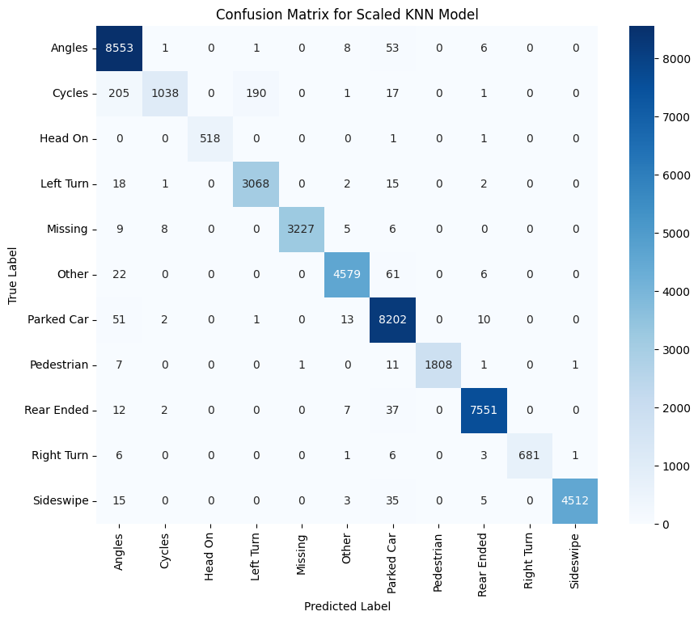

```python
# Ensure y_test is also in string format
y_test_inv = label_encoder.inverse_transform(y_test_encoded)

# Now you can calculate the confusion matrix
cm = confusion_matrix(y_test_inv, y_pred)

# Plotting the confusion matrix
plt.figure(figsize=(10, 8))
sn.heatmap(cm, annot=True, fmt='g', cmap='Blues', xticklabels=label_encoder.classes_, yticklabels=label_encoder.classes_)
plt.xlabel('Predicted Label')
plt.ylabel('True Label')
plt.title('Confusion Matrix for Scaled KNN Model')
plt.show()
```

After implementing feature scaling with the K-Nearest Neighbors (KNN) model, the results show a significant improvement in the model's performance.

- Feature scaling had a profound impact on the performance of the KNN model, significantly enhancing its classification accuracy.
- The improvement is especially notable in categories that previously had lower performance metrics.

### Comparison between each model:

**Initial KNN Model Performance:**

- The KNN model initially showed an accuracy of about 46.03%. This indicated challenges in handling the dataset's complexity and prompted the exploration of scaling and tuning.

**Hyperparameter Tuning Results:**

- The hyperparameter tuning of the KNN model, focusing on the number of neighbors and the distance metrics, further refined its performance. The tuned model displayed an improved accuracy of around 74.52%, showcasing the benefits of meticulous hyperparameter optimization.

**Impact of Feature Scaling:**

- Implementing feature scaling significantly enhanced the model's performance, boosting accuracy to approximately 98.05%. This was especially true for categories with lower initial performance metrics, underscoring the importance of appropriate data preprocessing.

### Decision Trees

Decision Trees are a type of supervised learning algorithm known for their simplicity, interpretability, and versatility in handling both classification and regression tasks.

```python
from sklearn.tree import DecisionTreeClassifier
from sklearn.metrics import classification_report, accuracy_score

# Creating the model
tree_model = DecisionTreeClassifier(random_state=0)

# Model fitting
tree_model.fit(X_train, y_train_encoded)

# testing predictions
y_pred = tree_model.predict(X_test)

y_pred_inv = label_encoder.inverse_transform(y_pred)

# Model evaluation
print("Classification Report:\n", classification_report(y_test_encoded, y_pred))
print("Accuracy:", accuracy_score(y_test_encoded, y_pred))
print("First 5 predictions:", y_pred[:5])
print("First 5 predictions:", y_pred_inv[:5])
```

```
Classification Report:
               precision    recall  f1-score   support

           0       1.00      1.00      1.00      8622
           1       1.00      0.51      0.68      1452
           2       1.00      1.00      1.00       520
           3       1.00      1.00      1.00      3106
           4       1.00      1.00      1.00      3255
           5       0.87      1.00      0.93      4668
           6       1.00      1.00      1.00      8279
           7       0.99      1.00      0.99      1829
           8       1.00      1.00      1.00      7609
           9       1.00      1.00      1.00       698
          10       1.00      1.00      1.00      4570

    accuracy                           0.98     44608
   macro avg       0.99      0.95      0.96     44608
weighted avg       0.99      0.98      0.98     44608

Accuracy: 0.9837921449067432
First 5 predictions: [0 5 4 8 5]
First 5 predictions: ['Angles' 'Other' 'Missing' 'Rear Ended' 'Other']
```

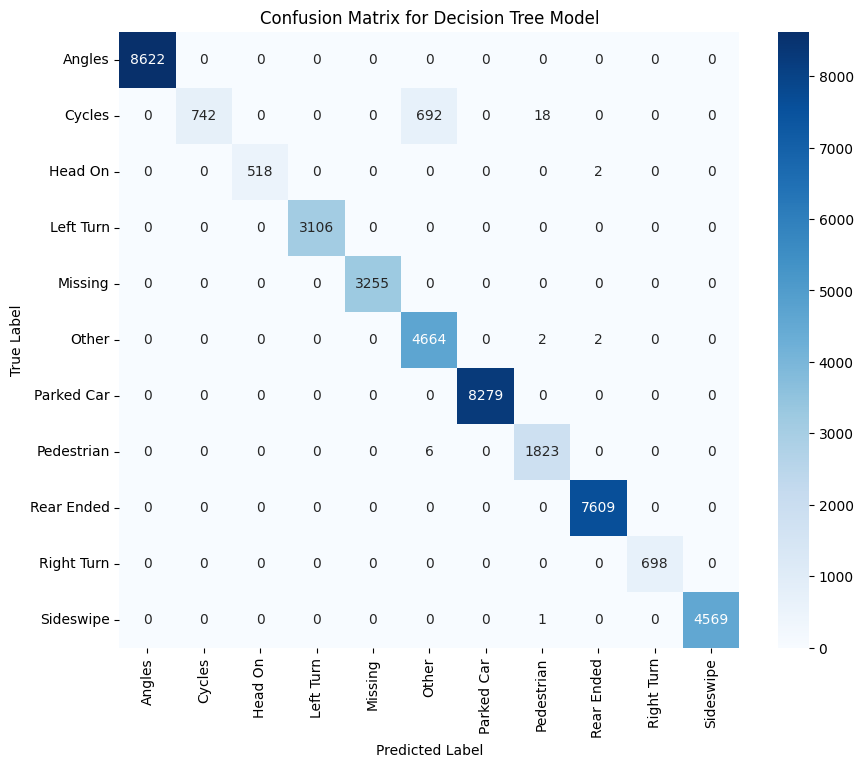

```python
y_pred_inv = label_encoder.inverse_transform(y_pred)
y_test_inv = label_encoder.inverse_transform(y_test_encoded)

# Now you can calculate the confusion matrix using decoded labels
cm = confusion_matrix(y_test_inv, y_pred_inv)

# Plotting the confusion matrix
plt.figure(figsize=(10, 8))
sn.heatmap(cm, annot=True, fmt='g', cmap='Blues', xticklabels=label_encoder.classes_, yticklabels=label_encoder.classes_)
plt.xlabel('Predicted Label')
plt.ylabel('True Label')
plt.title('Confusion Matrix for Decision Tree Model')
plt.show()
```

- Approximately 98.38% on the test data.
- High precision and recall in most categories.
- Lower recall in 'Cycles' (precision: 1.00, recall: 0.51).

**Conclusions**:

- High precision and recall in most categories.
- Demonstrated robustness in handling the dataset.
- Potential overfitting might need addressing through pruning or cross-validation.

The Decision Tree model's high accuracy and category-specific effectiveness suggest its potential as a robust predictive tool for traffic collision data, with room for further improvement and ensuring model generalization.

To test for overfitting using cross-validation on the Decision Tree model, we can perform k-fold cross-validation.

### Cross-validation

```python
from sklearn.metrics import accuracy_score
from sklearn.model_selection import cross_val_score



y_pred = tree_model.predict(X_test)

# Recalculating test accuracy
test_accuracy = accuracy_score(y_test_encoded, y_pred)

# Print the recalculated test accuracy
print("Recalculated Test Data Accuracy:", test_accuracy)

# Number of folds for cross-validation
num_folds = 5

# Perform cross-validation
cv_scores = cross_val_score(tree_model, X_train, y_train_encoded, cv=num_folds, scoring='accuracy')

# Calculate the mean cross-validation score
mean_cv_score = cv_scores.mean()

# Print the cross-validation results
print("Cross-Validation Scores:", cv_scores)
print("Mean Cross-Validation Score:", mean_cv_score)
```

```
Recalculated Test Data Accuracy: 0.9837921449067432
Cross-Validation Scores: [0.99976677 0.99983341 0.99973345 0.99963349 0.99980009]
Mean Cross-Validation Score: 0.9997534401759237
```

- The Decision Tree model shows excellent performance on both the training and test datasets.
- High cross-validation scores suggest that the model generalizes well over different subsets of the training data.
- The consistency between test accuracy and cross-validation scores indicates the model is not overfitting significantly.
- Overall, the model appears to be robust and reliable for the given dataset.

### Neural Networks

For the next phase of the project, we are exploring Neural Networks, which represent a significant leap in complexity and capability from traditional machine learning models. Neural Networks, particularly deep learning models, have gained immense popularity due to their ability to model complex, non-linear relationships in data. For this model we will use Perceptron. A Perceptron is a simple type of Neural Network often used for classification tasks. It's the foundational building block for more complex neural networks.

```python
from sklearn.linear_model import Perceptron # we use basic library : Perceptron
from sklearn.metrics import classification_report, accuracy_score

# Creating the model
perceptron_model = Perceptron()

# Model fitting
perceptron_model.fit(X_train, y_train_encoded)

# testing predictions
y_pred = perceptron_model.predict(X_test)

y_pred_inv = label_encoder.inverse_transform(y_pred)

# Model evaluation
print("Classification Report:\n", classification_report(y_test_encoded, y_pred))
print("Accuracy:", accuracy_score(y_test_encoded, y_pred))
print("First 5 predictions:", y_pred[:5])
print("First 5 predictions:", y_pred_inv[:5])
```

```
Classification Report:
               precision    recall  f1-score   support

           0       1.00      0.70      0.83      8622
           1       0.58      0.99      0.73      1452
           2       0.00      0.00      0.00       520
           3       0.49      0.85      0.62      3106
           4       0.90      0.99      0.94      3255
           5       1.00      0.43      0.60      4668
           6       1.00      0.03      0.05      8279
           7       0.09      0.99      0.17      1829
           8       0.50      0.00      0.00      7609
           9       0.00      0.00      0.00       698
          10       0.40      0.46      0.43      4570

    accuracy                           0.44     44608
   macro avg       0.54      0.50      0.40     44608
weighted avg       0.73      0.44      0.42     44608

Accuracy: 0.43797076757532283
First 5 predictions: [0 1 4 7 1]
First 5 predictions: ['Angles' 'Cycles' 'Missing' 'Pedestrian' 'Cycles']
```

[output not shown]

- Achieved an accuracy of approximately 43.8%. This indicates challenges in classifying various collision types.
- Strong in predicting categories like 'Cycles' and 'Missing'. However, significantly underperformed or failed in others like 'Head On', 'Right Turn', and 'Rear Ended'.
- The inconsistency in precision and recall across categories suggests limitations in the Perceptron's linear approach for this complex dataset.
- Encountered warnings indicate no predictions for some categories, highlighting the model's limitations.

Next, we can try and scale the data.

Scaled model

```python
from sklearn.linear_model import Perceptron
from sklearn.metrics import classification_report, accuracy_score
from sklearn.preprocessing import StandardScaler
from sklearn.pipeline import Pipeline

# Creating a pipeline with scaler and Perceptron
pipeline = Pipeline([
    ('scaler', StandardScaler()),
    ('perceptron', Perceptron())
])

# Fitting the pipeline to the training data
pipeline.fit(X_train, y_train_encoded)

# Making predictions on the test set
y_pred_encoded = pipeline.predict(X_test)

# Extracting the encoded labels for the test set
y_test_numeric = y_test_encoded

# Evaluating the model
print("Classification Report:\n", classification_report(y_test_numeric, y_pred_encoded))
print("Accuracy:", accuracy_score(y_test_numeric, y_pred_encoded))

# Decoding the predictions for interpretability
y_pred_inv = label_encoder.inverse_transform(y_pred_encoded)
print("First 5 predictions:", y_pred_inv[:5])
```

```
Classification Report:
               precision    recall  f1-score   support

           0       1.00      1.00      1.00      8622
           1       1.00      0.95      0.97      1452
           2       1.00      1.00      1.00       520
           3       1.00      1.00      1.00      3106
           4       1.00      1.00      1.00      3255
           5       0.99      1.00      0.99      4668
           6       1.00      1.00      1.00      8279
           7       1.00      1.00      1.00      1829
           8       1.00      1.00      1.00      7609
           9       1.00      1.00      1.00       698
          10       1.00      1.00      1.00      4570

    accuracy                           1.00     44608
   macro avg       1.00      1.00      1.00     44608
weighted avg       1.00      1.00      1.00     44608

Accuracy: 0.997870337159254
First 5 predictions: ['Angles' 'Cycles' 'Missing' 'Rear Ended' 'Cycles']
```

```python
from sklearn.model_selection import cross_val_score

# Use the same pipeline with StandardScaler and Perceptron
pipeline = Pipeline([
    ('scaler', StandardScaler()),
    ('perceptron', Perceptron())
])

# Number of folds for cross-validation
num_folds = 5

# Perform cross-validation
cv_scores = cross_val_score(pipeline, X_train, y_train_encoded, cv=num_folds, scoring='accuracy')

# Calculate the mean cross-validation score
mean_cv_score = cv_scores.mean()

# Print the cross-validation results
print("Cross-Validation Scores:", cv_scores)
print("Mean Cross-Validation Score:", mean_cv_score)
```

```
Cross-Validation Scores: [0.99953354 0.99966681 0.99966681 0.99986672 0.99956685]
Mean Cross-Validation Score: 0.9996601472695165
```

- The Perceptron model, after being scaled, exhibited an exceptional improvement in performance, with near-perfect precision and recall across all collision categories.
- The overall accuracy of the model reached approximately 99.79%, indicating a high level of effectiveness in classification tasks.
- This marked improvement, particularly in categories that previously showed weaker performance, underscores the impact of feature scaling on the efficiency of neural network models like Perceptrons.
- However, such high accuracy might also raise questions about potential overfitting, and it's important to validate the model's performance on an independent or more varied dataset to ensure generalizability.

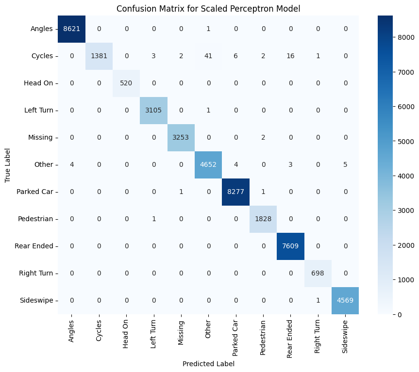

```python
y_test_labels = label_encoder.inverse_transform(y_test_encoded)

# Calculating the confusion matrix
cm = confusion_matrix(y_test_labels, y_pred_inv)

# Plotting the confusion matrix
plt.figure(figsize=(10, 8))
sn.heatmap(cm, annot=True, fmt='g', cmap='Blues', xticklabels=label_encoder.classes_, yticklabels=label_encoder.classes_)
plt.xlabel('Predicted Label')
plt.ylabel('True Label')
plt.title('Confusion Matrix for Scaled Perceptron Model')
plt.show()
```

```python
from sklearn.linear_model import Perceptron
from sklearn.model_selection import GridSearchCV
from sklearn.metrics import classification_report, accuracy_score

# Define the hyperparameter grid
param_grid = {
    'penalty': [None, 'l2', 'l1', 'elasticnet'],
    'alpha': [0.0001, 0.001, 0.01],  # Regularization term
    'max_iter': [1000, 2000, 3000],  # Maximum number of iterations
    'eta0': [1.0, 0.1, 0.01]  # Initial learning rate
}

# Initialize the Perceptron model
perceptron = Perceptron()

# Create GridSearchCV with the Perceptron model and hyperparameter grid
grid_search = GridSearchCV(perceptron, param_grid, cv=5, scoring='accuracy', n_jobs=-1)

# Fit GridSearchCV using the training data
grid_search.fit(X_train, y_train_encoded)

# Identify the best hyperparameter values
best_params = grid_search.best_params_
best_perceptron = grid_search.best_estimator_

# Fit the model with the best hyperparameters
best_perceptron.fit(X_train, y_train_encoded)

# Predict on the test set
y_pred = best_perceptron.predict(X_test)

# Decode the predictions back to original labels for evaluation
y_pred_inv = label_encoder.inverse_transform(y_pred)

# Model evaluation
print("Best Hyperparameters:", best_params)
print("Classification Report:\n", classification_report(y_test_encoded, y_pred))
print("Accuracy:", accuracy_score(y_test_encoded, y_pred))
```

[output not shown]

[output cut: 88 more lines]

## Final Conclusion

### Data Preparation and Exploratory Data Analysis

- We successfully managed the initial phase of handling over 190,000 records of traffic collision data.
- Our effective management of missing values, encoding of categorical variables, and exploratory data analysis laid a basis for the subsequent modeling.

### Model Application and Evaluation

References: Source of the data is https://www.kaggle.com/datasets/ravijonnalagadda/capstone-car-accident-serveity/code